# Segmental and whole-genome duplications in Mucoromycota

2026-11-26

# Overview

Duplicated genes were classified in 61 genomes of Mortierellales, Umbelopsidales and Mucorales, compared across genomes, and traced back to the branches of the species tree where they arose. Because gene order is scrambled in many of these genomes, duplications that arose in blocks were identified with a measure of synteny that does not depend on gene order, and their Ks distributions were used to date the large-scale duplication events. The extended analyses behind this report (assembly QC, gene-tree duplication rates, macrosynteny, copy-number tests, robustness checks) are in `wgd_mucoromycota.Rmd`.

```r
fetch(c("data/metadata/genome_metadata_master.csv",
        "data/metadata/assembly_qc_summary.csv",
        "data/phylogeny/sco_cds_b500.date.nwk",
        "data/orthofinder/results/Comparative_Genomics_Statistics/Statistics_PerSpecies.tsv"))

md <- fread("data/metadata/genome_metadata_master.csv")
gen <- md[include_core_analyses == "yes",
          .(genome = tree_label, dt_id = genome_id, species = species_name, family,
            order = factor(order, order_levels))]
tree <- read.tree("data/phylogeny/sco_cds_b500.date.nwk")
stopifnot(setequal(gen$genome, tree$tip.label), !anyNA(gen$order))

# Number of protein-coding genes (OrthoFinder input proteomes)
ps <- fread("data/orthofinder/results/Comparative_Genomics_Statistics/Statistics_PerSpecies.tsv",
            header = TRUE, nrows = 10)
setnames(ps, 1, "stat")
ng <- unlist(ps[stat == "Number of genes", -1])
# OrthoFinder species names (e.g. AbsRepe_prot, gzAbsCyli1.proteins) by genome
of_names <- setNames(names(ng), sub("[._](prot|proteins|pep)$", "", names(ng)))
names(ng) <- names(of_names)
gen[, genes := as.numeric(ng[genome])]
stopifnot(!anyNA(gen$genes))

qc <- fread("data/metadata/assembly_qc_summary.csv")
gen[, busco_dup := qc$Busco_Dup[match(genome, qc$genome_id)]]

# Genomes in tree order (bottom to top), for plots
tip_data <- ggtree(tree)$data
tip_order <- with(tip_data[tip_data$isTip, ], label[order(y)])
```

```r
# Sequence lengths of every assembly. Computed once on NeLS (awk over each
# assembly FASTA, so the ~3 GB of assemblies are not downloaded) and saved to
# data/. This is the one NeLS-specific step; at publication the table is
# deposited with the other data files.
cl_path <- "data/genome_duplication/contig_lengths.tsv"
if (!file.exists(cl_path)) {
  remote <- paste(
    "cd", shQuote(nels_path("data/genomes")), "&& printf 'genome\\tseqname\\tlength\\n' &&",
    "for g in *; do",
    "f=$(ls \"$g\" | grep -E '\\.(fna|fasta|fa|fas)(\\.gz)?$' | grep -viE 'cds|transcript|protein|rna_from');",
    "[ $(echo $f | wc -w) -eq 1 ] || { echo \"No unique assembly in $g\" >&2; exit 1; };",
    "case \"$f\" in *.gz) r='gzip -dc';; *) r=cat;; esac;",
    "$r \"$g/$f\" | awk -v g=\"$g\" '/^>/ {if (n != \"\") print g \"\\t\" n \"\\t\" l; n = substr($1, 2); l = 0; next}",
    "{l += length($0)} END {if (n != \"\") print g \"\\t\" n \"\\t\" l}';",
    "done")
  dir.create(dirname(cl_path), recursive = TRUE, showWarnings = FALSE)
  writeLines(.nels_run(remote), cl_path)
}
cl <- fread(cl_path, colClasses = c(seqname = "character"))
stopifnot(all(gen$genome %in% cl$genome))
```

```r
fetch(sprintf("data/genomes/%1$s/%1$s_genePosTbl.tsv", gen$genome))
gp <- rbindlist(lapply(gen$genome, function(g) {
  fread(sprintf("data/genomes/%1$s/%1$s_genePosTbl.tsv", g),
        colClasses = c(seqname = "character"))[, genome := g]
}))
gp <- merge(gp, cl, by = c("genome", "seqname"), all.x = TRUE)
stopifnot(mean(!is.na(gp$length)) > 0.99)  # gene tables and assemblies use the same names
```

```r
dup_files  <- sprintf("data/doubletrouble/dups/%s_dup.rds", gen$dt_id)
kaks_files <- sprintf("data/doubletrouble/kaks/%s_kaks.rds", gen$dt_id)
fetch(c(dup_files, kaks_files))

pairs <- rbindlist(lapply(seq_len(nrow(gen)), function(i) {
  d <- as.data.table(readRDS(dup_files[i]))
  k <- as.data.table(readRDS(kaks_files[i])[[1]])
  d <- merge(d, k[, .(dup1, dup2, Ka, Ks)], by = c("dup1", "dup2"), all.x = TRUE)
  d[, .(genome = gen$genome[i], dup1, dup2, type = as.character(type),
        seq1 = as.character(seqname1), seq2 = as.character(seqname2), Ka, Ks)]
}))
# Near-identical pairs: Ks < 0.05, or Ks not estimable (mostly identical
# sequences, see Section 1.2). These are recent duplicates or assembly
# duplicates and are kept apart from the older pairs.
pairs[, near_ident := is.na(Ks) | Ks < 0.05]
```

```r
n50 <- function(x) { x <- sort(x, decreasing = TRUE); x[which(cumsum(x) >= sum(x) / 2)[1]] }
asm <- cl[, .(n_seq = .N, size_mb = sum(length) / 1e6, n50_mb = n50(length) / 1e6), by = genome]
gcont <- gp[, .(gene_seqs = uniqueN(seqname), on_1mb = mean(length >= 1e6, na.rm = TRUE)),
            by = genome]
gen <- merge(gen, asm, by = "genome", all.x = TRUE)
gen <- merge(gen, gcont, by = "genome", all.x = TRUE)
```

```r
ni <- pairs[near_ident == TRUE]
ni_sd <- ni[type == "SD", .(ni_sd = .N, ni_sd_seq_pairs = uniqueN(paste(pmin(seq1, seq2), pmax(seq1, seq2)))),
            by = genome]
gen <- merge(gen, ni_sd, by = "genome", all.x = TRUE)
gen[is.na(ni_sd), `:=`(ni_sd = 0L, ni_sd_seq_pairs = 0L)]
gen <- merge(gen, pairs[, .(pairs = .N, ni_all = sum(near_ident),
                            sd_old = sum(type == "SD" & !near_ident)), by = genome],
             by = "genome")
```

# 1 Classifying duplicated genes

Duplicate gene pairs were identified and classified within each genome with doubletrouble 1.8.1 (standard scheme, default parameters):

- **Paralogous pairs:** each proteome against itself with DIAMOND (top 5 hits per protein, E-value <= 1e-10).
- **SD, segmental:** anchor pairs of collinear blocks within the genome (MCScanX algorithm in syntenet; at least 5 anchors, up to 25 genes apart).
- **TD, tandem:** remaining pairs that are adjacent on the same sequence.
- **PD, proximal:** remaining pairs 1 to 9 genes apart on the same sequence.
- **DD, dispersed:** all other pairs.
- **Ks:** pairwise codon alignments, MYN model (KaKs_Calculator via MSA2dist).

Pairs with Ks < 0.05 or no estimable Ks (mostly identical sequences) are kept apart as *near-identical*: they are very recent duplicates or duplicated stretches of an assembly. Each duplicated gene was given one mode, in the order SD > TD > PD > DD (Figure 1).

```r
gpairs <- rbind(pairs[, .(genome, gene = dup1, type, near_ident)],
                pairs[, .(genome, gene = dup2, type, near_ident)])
gpairs[, mode := fifelse(near_ident, "Near-identical", type)]
gpairs[, rank := match(mode, mode_levels)]
gmode <- gpairs[, .(mode = mode[which.min(rank)]), by = .(genome, gene)]
land <- gmode[, .N, by = .(genome, mode)]
land <- merge(land, gen[, .(genome, genes, order)], by = "genome")
land[, pct := 100 * N / genes]
land_wide <- dcast(land, genome + order + genes ~ mode, value.var = "pct", fill = 0)
for (m in mode_levels) if (!m %in% names(land_wide)) land_wide[, (m) := 0]
land_wide[, dup_pct := SD + TD + PD + DD]
```

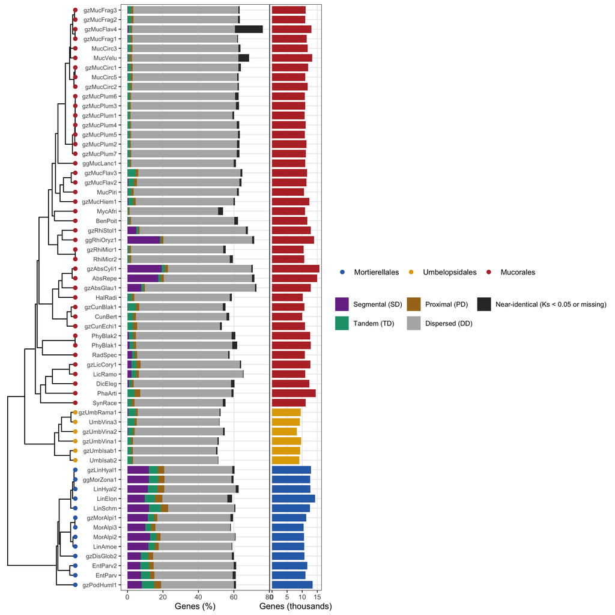

**Figure 1.** Duplicated genes per genome on the dated species tree. Middle: percentage of genes in each duplication mode (each gene counted once, priority SD > TD > PD > DD; near-identical only for genes in no older pair). Right: number of protein-coding genes. Tip colour: order.

```r
tip_df <- data.frame(label = gen$genome, order = gen$order)
p_tree <- ggtree(tree) %<+% tip_df +
  geom_tippoint(aes(colour = order), size = 1.8) +
  scale_colour_manual(values = order_cols, name = NULL) +
  theme(legend.position = "bottom")
p_modes <- ggplot(land[, .(genome, mode = factor(mode, rev(mode_levels)), pct)],
                  aes(pct, genome, fill = mode)) +
  geom_col(width = 0.8) +
  scale_fill_manual(values = mode_cols, labels = mode_labs, name = NULL, breaks = mode_levels) +
  labs(x = "Genes (%)", y = NULL) +
  theme(legend.position = "bottom", axis.text.y = element_text(size = 7)) +
  guides(fill = guide_legend(nrow = 2))
p_genes <- ggplot(gen, aes(genes / 1000, genome, fill = order)) +
  geom_col(width = 0.8, show.legend = FALSE) +
  scale_fill_manual(values = order_cols) +
  labs(x = "Genes (thousands)", y = NULL) +
  theme(axis.text.y = element_blank(), axis.ticks.y = element_blank())
p_modes %>% insert_left(p_tree, width = 0.5) %>% insert_right(p_genes, width = 0.35)
```

# 2 Differences across genomes

```r
ord_tab <- land_wide[, .(genomes = .N,
                         genes = median(genes),
                         duplicated = median(dup_pct), SD = median(SD), TD = median(TD),
                         PD = median(PD), DD = median(DD), near_identical = median(`Near-identical`)),
                     by = order][order(order)]
num <- names(ord_tab)[sapply(ord_tab, is.numeric)]
ord_tab[, (num) := lapply(.SD, round, 1), .SDcols = num]
knitr::kable(ord_tab, caption = tcap("orders", "Median number of genes and median percentage of genes in each duplication mode, per order."))
```

Table 1. Median number of genes and median percentage of genes in each duplication mode, per order.

| order | genomes | genes | duplicated | SD | TD | PD | DD | near_identical |
| --- | --- | --- | --- | --- | --- | --- | --- | --- |
| Mortierellales | 13 | 11655 | 59.1 | 11.4 | 5.0 | 2.8 | 41.1 | 1.2 |
| Umbelopsidales | 6 | 9290 | 51.3 | 0.1 | 2.4 | 1.1 | 47.3 | 0.6 |
| Mucorales | 42 | 11280 | 61.6 | 0.2 | 1.6 | 1.2 | 57.9 | 1.2 |

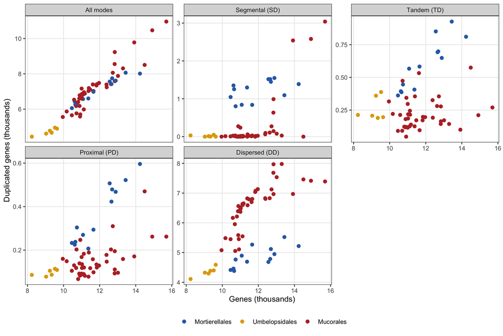

**Figure 2.** Duplicated genes (excluding near-identical) against the number of genes, per duplication mode and in total. Each point is a genome.

```r
dup_counts <- dcast(land, genome + order + genes ~ mode, value.var = "N", fill = 0)
for (m in mode_levels) if (!m %in% names(dup_counts)) dup_counts[, (m) := 0]
dup_counts[, All := SD + TD + PD + DD]
dlong <- melt(dup_counts, id.vars = c("genome", "order", "genes"),
              measure.vars = c("All", "SD", "TD", "PD", "DD"), variable.name = "mode", value.name = "dup_genes")
dlong[, mode := factor(mode, c("All", "SD", "TD", "PD", "DD"),
                       c("All modes", mode_labs[c("SD", "TD", "PD", "DD")]))]
ggplot(dlong, aes(genes / 1000, dup_genes / 1000)) +
  geom_point(aes(colour = order), size = 1.8) +
  facet_wrap(~mode, scales = "free_y", nrow = 2) +
  scale_colour_manual(values = order_cols, name = NULL) +
  labs(x = "Genes (thousands)", y = "Duplicated genes (thousands)") +
  theme(legend.position = "bottom")
```

50-72% of the genes of each genome are in a paralogous pair, most of them dispersed (Table 1). The total is similar in the three orders, but its make-up differs: Mortierellales have more segmental, tandem and proximal duplicates and fewer dispersed ones than Mucorales with the same number of genes (Figure 2). Genomes with more genes have more duplicated genes, mostly dispersed ones.

# 3 Segmental duplicates are concentrated in a few lineages

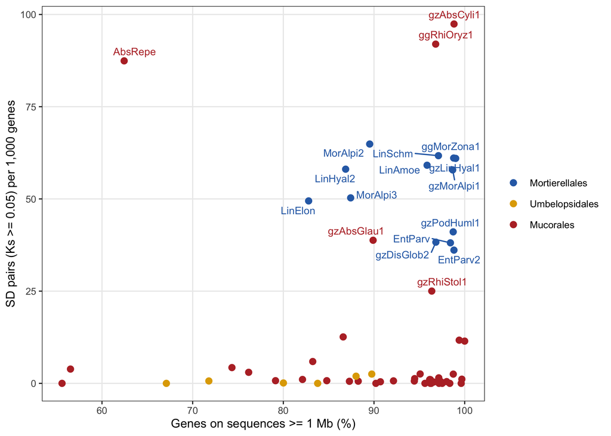

**Figure 3.** Segmental duplicate pairs (Ks >= 0.05) per 1,000 genes against the percentage of genes on sequences of at least 1 Mb, where collinear blocks can be detected. Each point is a genome; genomes with more than 20 pairs per 1,000 genes are labelled.

```r
gen[, sd_per_1k := 1000 * sd_old / genes]
ggplot(gen, aes(100 * on_1mb, sd_per_1k, colour = order)) +
  geom_point(size = 2.2) +
  geom_text_repel(data = gen[sd_per_1k > 20], aes(label = genome), size = 3,
                  show.legend = FALSE, max.overlaps = 30) +
  scale_colour_manual(values = order_cols, name = NULL) +
  labs(x = "Genes on sequences >= 1 Mb (%)", y = "SD pairs (Ks >= 0.05) per 1,000 genes")
```

```r
# Well-assembled genomes: at least 75% of genes on sequences >= 1 Mb. (The
# Umbelopsidales genomes are small, with chromosomes of 1-2 Mb, so a stricter
# cutoff would exclude all of them.)
hi_cont <- gen[on_1mb >= 0.75]
sd_by_order_hi <- hi_cont[, .(n = .N, median_sd_per_1k = median(sd_per_1k)), by = order][order(order)]
# Share of segmental pairs that are near-identical, per order
sd_ni_share <- pairs[type == "SD"][gen[, .(genome, order)], on = "genome", nomatch = NULL][
  , .(share = mean(near_ident)), by = .(genome, order)][, .(median_share = median(share)), by = order]
```

```r
# Segmental (SD) pairs and the genes in them, per order and in total (Table S1)
sd_genes <- function(d) uniqueN(c(paste(d$genome, d$dup1), paste(d$genome, d$dup2)))
sd_count <- function(d, genomes) data.table(
  genomes = length(genomes), with_sd = uniqueN(d$genome),
  sd_pairs = nrow(d), sd_genes = sd_genes(d),
  sd_pairs_old = sum(!d$near_ident), sd_genes_old = sd_genes(d[near_ident == FALSE]))
sd_all <- pairs[type == "SD"][, order := gen$order[match(genome, gen$genome)]]
sd_s1 <- rbind(
  rbindlist(lapply(order_levels, function(o)
    cbind(order = o, sd_count(sd_all[order == o], gen[order == o, genome])))),
  # gzMucFlav4 alone holds most near-identical pairs (uncollapsed haplotypes)
  cbind(order = "Mucorales without gzMucFlav4",
        sd_count(sd_all[order == "Mucorales" & genome != "gzMucFlav4"],
                 gen[order == "Mucorales" & genome != "gzMucFlav4", genome])),
  cbind(order = "Total", sd_count(sd_all, gen$genome)))
sd_tot <- sd_s1[order == "Total"]
```

In total, doubletrouble found 18,966 segmental pairs (35,985 genes) in 53 of the 61 genomes, 13,912 pairs (27,471 genes) after excluding near-identical pairs (Table S1). Among the 55 well-assembled genomes (at least 75% of genes on sequences of 1 Mb or more), segmental duplicates are common in Mortierellales (median 57.9 pairs per 1,000 genes) and in *Absidia* and *Rhizopus*, and rare in the other Mucorales (0.7) and in Umbelopsidales (1; Figure 3). Their scarcity is therefore not an assembly artifact. In Mucorales, a median 36% of segmental pairs per genome are near-identical, against 6% in Mortierellales; most extreme is gzMucFlav4, with 2,723 near-identical segmental pairs that point to duplicated (uncollapsed haplotype) sequences in its assembly.

# 4 Ancestral segmental duplications

## 4.1 Why collinearity misses old segmental duplicates

A pair is segmental only if it lies in a collinear block of at least five pairs in the same order. Gene order within chromosomes is scrambled much faster in Mucorales and Umbelopsidales than in Mortierellales (synteny analysis), so blocks from old segmental duplications or WGDs break into pieces too short for this rule, and their pairs are classified as dispersed even though the duplicated regions still share genes. The same ancestral duplication can then be segmental in one genome and dispersed in another.

## 4.2 Duplications on the species tree

Each OrthoFinder gene-tree duplication with at least 50% support (both copies retained in at least half of the descendant species) was assigned to the species-tree branch on which it happened. Within each descendant genome, the pairs of genes across its two copies were matched to the doubletrouble pairs.

```r
fetch(c("data/orthofinder/results/Species_Tree/SpeciesTree_rooted_node_labels.txt",
        "data/orthofinder/results/Gene_Duplication_Events/Duplications.tsv",
        "data/orthofinder/results/Orthogroups/Orthogroups.GeneCount.tsv"))
of_suffix <- "[._](prot|proteins|pep)$"
of_tree <- read.tree("data/orthofinder/results/Species_Tree/SpeciesTree_rooted_node_labels.txt")
of_tree$tip.label <- sub(of_suffix, "", of_tree$tip.label)
nt <- Ntip(of_tree)
depth <- node.depth.edgelength(tree)
root_age <- max(depth)

# OrthoFinder nodes within the 61 core genomes, matched to the dated tree by
# their descendant genomes (nodes where the two topologies differ get no match)
nodes <- rbindlist(lapply(c(seq_len(nt), nt + seq_len(of_tree$Nnode)), function(i) {
  tl <- if (i <= nt) of_tree$tip.label[i] else extract.clade(of_tree, i)$tip.label
  if (!all(tl %in% tree$tip.label)) return(NULL)
  m <- if (length(tl) == 1) match(tl, tree$tip.label) else getMRCA(tree, tl)
  if (length(tl) > 1 && !setequal(extract.clade(tree, m)$tip.label, tl)) m <- NA_integer_
  ords <- unique(as.character(gen$order[match(tl, gen$genome)]))
  data.table(node = if (i <= nt) tl else of_tree$node.label[i - nt], ntips = length(tl),
             dt_node = m, clade_order = if (length(ords) == 1) ords else "Several orders")
}))
nodes[, brlen := tree$edge.length[match(dt_node, tree$edge[, 2])]]
nodes[, age_end := root_age - depth[dt_node]]
nodes[, age_start := age_end + brlen]

dups <- fread("data/orthofinder/results/Gene_Duplication_Events/Duplications.tsv")
setnames(dups, c("og", "of_node", "gt_node", "support", "dup_type", "genes1", "genes2"))
dups[, node := sub(of_suffix, "", of_node)]
sup <- dups[support >= 0.5 & node %in% nodes$node]
nodes <- merge(nodes, sup[, .(dups = .N, ogs = uniqueN(og), single = mean(table(og) == 1)), by = node],
               by = "node", all.x = TRUE)
nodes[is.na(dups), `:=`(dups = 0L, ogs = 0L)]
nodes[, `:=`(rate = dups / brlen, per_og = dups / ogs)]

key_nodes <- data.table(
  node = c("N8", "N9", "N12", "N11", "N10", "N40", "N46", "N32"),
  label = c("Mucoromycota (root)", "Umbelopsidales + Mucorales", "Mucorales", "Umbelopsidales",
            "Mortierellales", "Absidia (3 species)", "A. cylindrospora + A. repens",
            "R. oryzae + R. stolonifer"))
# Internal branches long enough for a rate (very short branches between
# strains of one species give meaningless rates)
internal <- nodes[ntips > 1 & !is.na(brlen) & brlen >= 5]
med_rate <- median(internal$rate)
internal[, rate_rank := frank(-rate)]
```

```r
# Collapsed clades, defined on the full tree
grp <- data.table(
  name = c("Mortierellales", "Umbelopsidales", "Lichtheimia and relatives", "Phycomyces, Radiomyces",
           "Cunninghamella", "Mucor and relatives", "Rhizopus microsporus"),
  tips = list(gen[order == "Mortierellales", genome], gen[order == "Umbelopsidales", genome],
              c("gzLicCory1", "SynRace"), c("PhyBlak1", "RadSpec"), c("CunBert", "gzCunBlak1", "gzCunEchi1"),
              c("gzMucCirc1", "MycAfri"), c("gzRhiMicr1", "RhiMicr2")),
  col = c(order_cols[["Mortierellales"]], order_cols[["Umbelopsidales"]], rep(order_cols[["Mucorales"]], 5)))
grp[, members := lapply(tips, function(tl) extract.clade(tree, getMRCA(tree, tl))$tip.label)]
grp[, n := lengths(members)]
# Display tree: two genomes per collapsed clade, one from each side of its root,
# so every triangle keeps its depth but takes the same space
rep_tips <- function(tl) {
  m <- getMRCA(tree, tl)
  vapply(tree$edge[tree$edge[, 1] == m, 2],
         function(ch) if (ch <= Ntip(tree)) tree$tip.label[ch] else extract.clade(tree, ch)$tip.label[1], "")
}
grp[, reps := lapply(tips, rep_tips)]
keep <- data.table(genome = c("HalRadi", "gzAbsGlau1", "gzAbsCyli1", "AbsRepe", "ggRhiOryz1", "gzRhiStol1"))
stree <- keep.tip(tree, c(unlist(grp$reps), keep$genome))
mrca <- function(tips) getMRCA(stree, intersect(tips, stree$tip.label))
grp[, node := vapply(reps, mrca, 0L)]
p0 <- ggtree(stree, ladderize = TRUE)
d0 <- as.data.table(p0$data)
grp[, y := vapply(reps, function(tl) mean(d0[label %in% tl, y]), 0)]
p <- p0
for (i in seq_len(nrow(grp))) {
  p <- collapse(p, grp$node[i], mode = "mixed", fill = grp$col[i], colour = grp$col[i], alpha = 0.35)
}
keep[, `:=`(y = d0$y[match(genome, d0$label)], species = gen$species[match(genome, gen$genome)])]
# Base figure shared by the reference tree and the summary: tip names and clade labels
p_base <- p +
  geom_tiplab(data = function(d) d[d$label %in% keep$genome, ], aes(label = gen$species[match(label, gen$genome)]),
              fontface = "italic", size = 3.2, offset = 12) +
  geom_text(data = grp, aes(x = 1012, y = y, label = sprintf("%s (%d)", name, n)), hjust = 0, size = 3.3,
            inherit.aes = FALSE) +
  coord_cartesian(xlim = c(-10, 1330), clip = "off") +
  theme(plot.margin = margin(5, 5, 5, 5))
```

The branches discussed below carry the OrthoFinder node labels shown in Figure 4. A duplication “on N12” happened on the branch leading to node N12, the Mucorales stem.

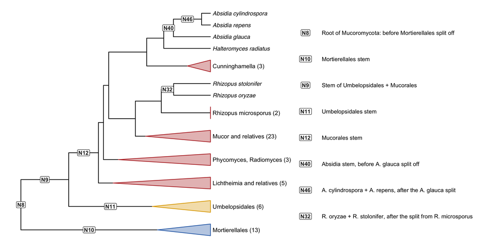

**Figure 4.** The species tree with the node labels used in this report (OrthoFinder species-tree nodes). Each label sits on the branch that leads to its node, where the duplications assigned to that node happened; N8 is the root. Clades without a labelled branch are collapsed into triangles (number of genomes in brackets). Branch lengths: dated tree, relative time.

```r
ref_desc <- data.table(
  node = c("N8", "N10", "N9", "N11", "N12", "N40", "N46", "N32"),
  desc = c("Root of Mucoromycota: before Mortierellales split off",
           "Mortierellales stem",
           "Stem of Umbelopsidales + Mucorales",
           "Umbelopsidales stem",
           "Mucorales stem",
           "Absidia stem, before A. glauca split off",
           "A. cylindrospora + A. repens, after the A. glauca split",
           "R. oryzae + R. stolonifer, after the split from R. microsporus"))
kn <- merge(ref_desc, nodes[, .(node, dt_node)], by = "node", sort = FALSE)
clade_tips <- function(n) if (n <= Ntip(tree)) tree$tip.label[n] else extract.clade(tree, n)$tip.label
kn[, snode := vapply(dt_node, function(n) mrca(clade_tips(n)), 0L)]
kn[, `:=`(x = d0$branch[match(snode, d0$node)], y = d0$y[match(snode, d0$node)])]
kn[node == "N8", x := d0$x[match(snode, d0$node)]]
p_ref <- p_base +
  geom_label(data = kn, aes(x, y, label = node), size = 3.1, fontface = "bold", colour = "grey15",
             fill = "white", label.padding = unit(0.15, "lines"), label.size = 0.3, inherit.aes = FALSE)
kn[, row := rev(seq_len(.N))]
p_key <- ggplot(kn) +
  geom_label(aes(0, row, label = node), size = 3.1, fontface = "bold", colour = "grey15", fill = "white",
             label.padding = unit(0.15, "lines"), label.size = 0.3) +
  geom_text(aes(0.09, row, label = desc), hjust = 0, size = 3.2) +
  scale_x_continuous(limits = c(-0.04, 1)) + scale_y_continuous(limits = c(0.4, nrow(kn) + 0.6)) +
  theme_void()
p_ref + p_key + plot_layout(widths = c(1.35, 1))
```

```r
fetch(sprintf("data/genomes/%1$s/%1$s_IDtbl.tsv", gen$genome))
alias_all <- rbindlist(lapply(gen$genome, function(g) {
  ids <- fread(sprintf("data/genomes/%1$s/%1$s_IDtbl.tsv", g))
  unique(rbind(ids[, .(id = proteinID, gene = geneID)], ids[, .(id = rnaID, gene = geneID)],
               ids[, .(id = geneID, gene = geneID)]))[, genome := g]
}))
# OrthoFinder writes genes as "<species>_<FASTA header>", with "." in the
# species name replaced by "_", separated by ", ". Pieces without a core-genome
# prefix are outgroup genes or parts of FASTA descriptions that contained ", ".
prefix <- data.table(genome = gen$genome, prefix = paste0(gsub(".", "_", of_names[gen$genome], fixed = TRUE), "_"))
sup_int <- sup[node %in% nodes[ntips > 1, node]]
sup_int[, event := .I]
gl <- rbind(sup_int[, .(event, node, side = 1L, x = genes1)], sup_int[, .(event, node, side = 2L, x = genes2)])
gl <- gl[, .(part = unlist(strsplit(x, ", ", fixed = TRUE))), by = .(event, node, side)]
gl[, genome := NA_character_]
for (i in seq_len(nrow(prefix))) gl[is.na(genome) & startsWith(part, prefix$prefix[i]), genome := prefix$genome[i]]
gl <- gl[!is.na(genome)]
gl[, id := sub(" .*", "", substring(part, nchar(prefix$prefix[match(genome, prefix$genome)]) + 1))]
gl <- merge(gl, alias_all, by = c("genome", "id"), all.x = TRUE)
gene_map_rate <- mean(!is.na(gl$gene))
gl <- gl[!is.na(gene)]

cross <- merge(gl[side == 1, .(event, node, genome, g1 = gene)], gl[side == 2, .(event, genome, g2 = gene)],
               by = c("event", "genome"), allow.cartesian = TRUE)
cross[, key := paste(pmin(g1, g2), pmax(g1, g2))]
cross <- unique(cross, by = c("genome", "key", "node"))
pair_key <- unique(pairs[, .(genome, key = paste(pmin(dup1, dup2), pmax(dup1, dup2)), type)], by = c("genome", "key"))
cross <- merge(cross, pair_key, by = c("genome", "key"), all.x = TRUE)
sd_node <- cross[, .(cross_pairs = .N, classified = sum(!is.na(type)), sd = sum(type == "SD", na.rm = TRUE)), by = node]
sd_node[, sd_share := sd / classified]
nodes <- merge(nodes, sd_node, by = "node", all.x = TRUE)
internal <- merge(internal, sd_node, by = "node", all.x = TRUE)
```

```r
fetch("data/orthofinder/results/Orthogroups/Orthogroups.tsv")
og_tab <- fread("data/orthofinder/results/Orthogroups/Orthogroups.tsv", sep = "\t", quote = "")
# Genes of each core genome per orthogroup (cells list FASTA headers, ", "-separated)
og_genes <- rbindlist(lapply(gen$genome, function(g) {
  cell <- og_tab[[of_names[[g]]]]
  keep <- cell != ""
  l <- data.table(og = og_tab$Orthogroup[keep], cell = cell[keep])[
    , .(id = sub(" .*", "", unlist(strsplit(cell, ", ", fixed = TRUE)))), by = og]
  a <- alias_all[genome == g]
  unique(l[id %in% a$id][, .(og, genome = g, gene = a$gene[match(id, a$id)])])
}))
og_genes <- merge(og_genes, gmode, by = c("genome", "gene"), all.x = TRUE)
og_genes[is.na(mode), mode := "Not duplicated"]
dup_in_og <- mean(paste(gmode$genome, gmode$gene) %in% paste(og_genes$genome, og_genes$gene))
```

## 4.3 Neighbourhood synteny

For each paralog pair (A, B), the genes within W genes of A and of B are compared, ignoring order and orientation. The support of the pair is the number of other gene families with a paralog pair linking A’s window to B’s window. A pair is *neighbourhood-syntenic* if its support reaches k: A and B lie in regions that were duplicated together with genes of at least k other families (Figure 5). Near-identical pairs were excluded, and pairs closer than 2W genes on one sequence were not tested. The rate expected by chance was measured after shuffling gene order in each genome (3 shuffles). The analysis uses W = 10 and k = 2.

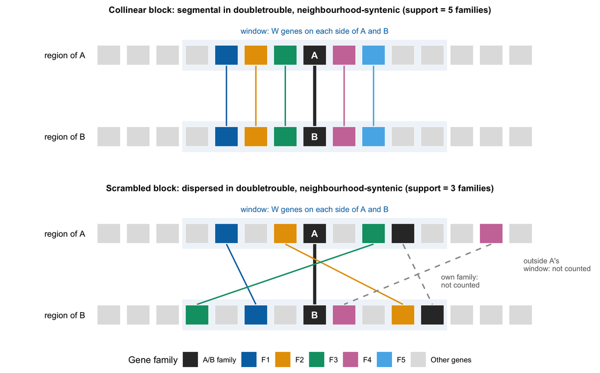

**Figure 5.** The neighbourhood synteny test for one paralog pair (A, B), drawn with a window of W = 4 genes (W = 10 in the analysis). Boxes: genes, coloured by gene family; shaded: the window around A and B. Lines: paralog pairs. A link counts as support if it joins A’s window to B’s window and belongs to another family than A and B. Top: a collinear block, segmental by doubletrouble’s rule and neighbourhood-syntenic. Bottom: the same kind of region after gene order has been scrambled; doubletrouble calls A-B dispersed, but three families still link the two windows, so A-B is neighbourhood-syntenic (k = 2). Links of A’s own family and links to genes outside a window are not counted.

```r
W_demo <- 4; ctr <- 8; n_pos <- 15
p_col <- "Collinear block: segmental in doubletrouble, neighbourhood-syntenic (support = 5 families)"
p_scr <- "Scrambled block: dispersed in doubletrouble, neighbourhood-syntenic (support = 3 families)"
row_genes <- function(fams) {
  f <- rep("Other genes", n_pos)
  for (p in names(fams)) f[as.integer(p)] <- fams[[p]]
  f
}
sch_genes <- rbind(
  data.table(panel = p_col, row = "A", pos = 1:n_pos,
             fam = row_genes(list(`5` = "F1", `6` = "F2", `7` = "F3", `8` = "A/B family", `9` = "F4", `10` = "F5"))),
  data.table(panel = p_col, row = "B", pos = 1:n_pos,
             fam = row_genes(list(`5` = "F1", `6` = "F2", `7` = "F3", `8` = "A/B family", `9` = "F4", `10` = "F5"))),
  data.table(panel = p_scr, row = "A", pos = 1:n_pos,
             fam = row_genes(list(`5` = "F1", `7` = "F2", `8` = "A/B family", `10` = "F3", `11` = "A/B family", `14` = "F4"))),
  data.table(panel = p_scr, row = "B", pos = 1:n_pos,
             fam = row_genes(list(`4` = "F3", `6` = "F1", `8` = "A/B family", `9` = "F4", `11` = "F2", `12` = "A/B family"))))
sch_links <- rbind(
  data.table(panel = p_col, from = c(8, 5, 6, 7, 9, 10), to = c(8, 5, 6, 7, 9, 10),
             kind = c("Focal pair A-B", rep("Supporting link", 5)), fam = c("A/B family", "F1", "F2", "F3", "F4", "F5")),
  data.table(panel = p_scr, from = c(8, 5, 7, 10, 11, 14), to = c(8, 6, 11, 4, 12, 9),
             kind = c("Focal pair A-B", rep("Supporting link", 3), "Not counted", "Not counted"),
             fam = c("A/B family", "F1", "F2", "F3", "A/B family", "F4")))
sch_links[, link_col := fifelse(kind == "Supporting link", fam, kind)]
sch_genes[, y := fifelse(row == "A", 1, 0)]
sch_genes[, label := fifelse(fam == "A/B family" & pos == ctr, row, "")]
fam_fill <- c("A/B family" = "grey20", F1 = "#0072B2", F2 = "#E69F00", F3 = "#009E73",
              F4 = "#CC79A7", F5 = "#56B4E9", "Other genes" = "grey88")
link_cols <- c(fam_fill[c("F1", "F2", "F3", "F4", "F5")], "Focal pair A-B" = "grey20", "Not counted" = "grey60")
panels <- factor(c(p_col, p_scr), c(p_col, p_scr))
sch_genes[, panel := factor(panel, levels(panels))]
sch_links[, panel := factor(panel, levels(panels))]
win <- CJ(panel = panels, y = c(0, 1))
notes <- data.table(panel = factor(p_scr, levels(panels)), x = c(12.3, 15.1), y = c(0.42, 0.62),
                    label = c("own family:\nnot counted", "outside A's\nwindow: not counted"))
ggplot() +
  geom_rect(data = win, aes(xmin = ctr - W_demo - 0.5, xmax = ctr + W_demo + 0.5, ymin = y - 0.19, ymax = y + 0.19),
            fill = "#0072B2", alpha = 0.08) +
  geom_segment(data = sch_links, aes(x = from, xend = to, y = 0.87, yend = 0.13, colour = link_col,
                                     linetype = kind == "Not counted", linewidth = kind == "Focal pair A-B")) +
  geom_tile(data = sch_genes, aes(pos, y, fill = fam), width = 0.78, height = 0.24, colour = "white") +
  geom_text(data = sch_genes, aes(pos, y, label = label), colour = "white", fontface = "bold", size = 3.6) +
  geom_text(data = notes, aes(x, y, label = label), size = 2.8, colour = "grey40", hjust = 0, lineheight = 0.9) +
  geom_text(data = CJ(panel = panels, y = c(1, 0))[, label := fifelse(y == 1, "region of A", "region of B")],
            aes(x = 0.2, y = y, label = label), hjust = 1, size = 3.2) +
  geom_text(data = data.table(panel = panels), aes(x = ctr, y = 1.3), label = "window: W genes on each side of A and B",
            size = 3, colour = "#0072B2") +
  facet_wrap(~panel, ncol = 1) +
  scale_fill_manual(values = fam_fill, breaks = names(fam_fill), name = "Gene family") +
  scale_colour_manual(values = link_cols, guide = "none") +
  scale_linetype_manual(values = c(`FALSE` = "solid", `TRUE` = "dashed"), guide = "none") +
  scale_linewidth_manual(values = c(`FALSE` = 0.7, `TRUE` = 1.6), guide = "none") +
  coord_cartesian(xlim = c(-1.6, 16.6), ylim = c(-0.3, 1.38), clip = "off") +
  theme_void(base_size = 10) +
  theme(legend.position = "bottom", strip.text = element_text(size = 9.5, face = "bold", margin = margin(b = 4)),
        panel.spacing = unit(1.2, "lines"), plot.margin = margin(6, 6, 6, 6)) +
  guides(fill = guide_legend(nrow = 1))
```

```r
nb_path <- "data/genome_duplication/neighbourhood_support.tsv.gz"
nb_k <- c(`10` = 2, `20` = 3, `30` = 4)
if (!file.exists(nb_path)) {
  nbhd_support <- function(pp, ord, fam, W) {
    pp <- merge(pp, ord[, .(a = gene, sa = seq, ra = rank)], by = "a")
    pp <- merge(pp, ord[, .(b = gene, sb = seq, rb = rank)], by = "b")
    pp[, `:=`(fam_ab = fam[a], tested = !(sa == sb & abs(ra - rb) <= 2 * W))]
    links <- rbind(pp[, .(x = a, y = b, sx = sa, rx = ra, sy = sb, ry = rb)],
                   pp[, .(x = b, y = a, sx = sb, rx = rb, sy = sa, ry = ra)])
    links[, fam_xy := fam[x]]
    foc <- pp[tested == TRUE, .(a, b, sa, sb, fam_ab, alo = ra - W, ahi = ra + W, blo = rb - W, bhi = rb + W)]
    j <- links[foc, on = .(sx == sa, rx >= alo, rx <= ahi, sy == sb, ry >= blo, ry <= bhi),
               nomatch = NULL, allow.cartesian = TRUE, .(a = i.a, b = i.b, x, y, fam_xy, fam_ab = i.fam_ab)]
    j <- j[x != a & y != b & x != b & y != a & (is.na(fam_xy) | is.na(fam_ab) | fam_xy != fam_ab)]
    j[is.na(fam_xy), fam_xy := paste0("gene:", pmin(x, y))]
    s <- j[, .(support = uniqueN(fam_xy)), by = .(a, b)]
    out <- merge(pp[tested == TRUE, .(a, b)], s, by = c("a", "b"), all.x = TRUE)
    out[is.na(support), support := 0L]
    out
  }
  nb <- rbindlist(lapply(gen$genome, function(g) {
    pp <- pairs[genome == g & !near_ident, .(a = dup1, b = dup2)]
    ord <- unique(gp[genome == g, .(gene = geneID, seq = seqname, start)], by = "gene")
    setorder(ord, seq, start)
    ord[, rank := seq_len(.N), by = seq]
    fam <- og_genes[genome == g, setNames(og, gene)]
    rbindlist(lapply(as.numeric(names(nb_k)), function(W) {
      runs <- list(real = ord)
      for (s in 1:3) { set.seed(s); o <- copy(ord); o[, gene := sample(gene)]; runs[[paste0("null", s)]] <- o }
      rbindlist(lapply(names(runs), function(r) nbhd_support(pp, runs[[r]], fam, W)[, `:=`(W = W, run = r)]))
    }))[, genome := g]
  }))
  fwrite(nb, nb_path, sep = "\t")
}
nb <- fread(nb_path)
nb[, `:=`(key = paste(pmin(a, b), pmax(a, b)), pass = support >= nb_k[as.character(W)], is_null = run != "real")]
nb <- merge(nb, pair_key, by = c("genome", "key"), all.x = TRUE)
nb <- merge(nb, gen[, .(genome, order)], by = "genome")
```

```r
calib <- nb[, .(chance = 100 * mean(pass[is_null]), real = 100 * mean(pass[!is_null]),
                SD = 100 * mean(pass[!is_null & type == "SD"]), DD = 100 * mean(pass[!is_null & type == "DD"])),
            by = .(W, k = nb_k[as.character(W)], order)][order(W, order)]
calib[, DD_over_chance := DD / chance]
num <- c("chance", "real", "SD", "DD", "DD_over_chance")
calib_show <- copy(calib[W == 10])[, (num) := lapply(.SD, function(v) signif(v, 3)), .SDcols = num]
knitr::kable(calib_show, caption = tcap("nb_calib", "Percentage of tested paralog pairs that are neighbourhood-syntenic, by order (window W = 10, threshold k = 2): in genomes with shuffled gene order (chance), in the real genomes (real), and among doubletrouble's segmental (SD) and dispersed (DD) pairs. DD_over_chance: dispersed pairs passing relative to chance."))
```

Table 2. Percentage of tested paralog pairs that are neighbourhood-syntenic, by order (window W = 10, threshold k = 2): in genomes with shuffled gene order (chance), in the real genomes (real), and among doubletrouble’s segmental (SD) and dispersed (DD) pairs. DD_over_chance: dispersed pairs passing relative to chance.

| W | k | order | chance | real | SD | DD | DD_over_chance |
| --- | --- | --- | --- | --- | --- | --- | --- |
| 10 | 2 | Mortierellales | 0.161 | 10.50 | 77.0 | 6.31 | 39.3 |
| 10 | 2 | Umbelopsidales | 0.141 | 1.56 | 44.7 | 1.51 | 10.7 |
| 10 | 2 | Mucorales | 0.158 | 4.77 | 89.3 | 3.70 | 23.5 |

With shuffled gene order only 0.14-0.16% of pairs pass, whereas 77-89% of doubletrouble’s segmental pairs in Mortierellales and Mucorales do (Table 2). Among dispersed pairs, 3.7% pass in Mucorales and 6.3% in Mortierellales, 23 and 39 times chance: many dispersed duplicates are eroded segmental duplicates. Wider windows (W = 20, k = 3; W = 30, k = 4) give the same conclusions.

## 4.4 Ancestral segmental duplications (ancestral-SD)

A gene-tree duplication is *ancestral-SD* if, in at least two descendant genomes, one of its pairs is segmental or neighbourhood-syntenic (in both tests excluding near-identical pairs). All its pairs, in every descendant genome, are then counted as ancestral-SD, including those that are dispersed today: the duplication arose in a block. Requiring two genomes keeps chance classifications rare. Figure S1 shows each step with its counts.

```r
nbx <- merge(cross[, .(genome, key, node, event)], nb[, .(genome, key, W, run, is_null, pass)],
             by = c("genome", "key"))
nb_node <- nbx[, .(tested = sum(!is_null) / 1, real = 100 * mean(pass[!is_null]), chance = 100 * mean(pass[is_null])),
               by = .(node, W)]
nb_node[, tested := tested]
nb_ev <- nbx[W == 10, .(any = any(pass)), by = .(node, event, run)][
  , .(events = sum(run == "real"), ev_real = 100 * mean(any[run == "real"]), ev_chance = 100 * mean(any[run != "real"])), by = node]
nb_w <- dcast(nb_node, node ~ W, value.var = c("real", "chance", "tested"))
nb_w <- merge(nb_w, nb_ev, by = "node")
nb_w <- merge(nb_w, nodes[, .(node, ntips, clade_order, age_start, age_end)], by = "node")
```

```r
real10 <- nbx[W == 10 & !is_null]
nb_real10 <- nb[W == 10 & !is_null, .(genome, key, nb_pass = pass)]
anc <- merge(cross[, .(genome, key, node, event, type)], nb_real10, by = c("genome", "key"), all.x = TRUE)
pair_ks <- unique(pairs[, .(genome, key = paste(pmin(dup1, dup2), pmax(dup1, dup2)), Ks)], by = c("genome", "key"))
anc <- merge(anc, pair_ks, by = c("genome", "key"), all.x = TRUE)
# segmental pairs count only if not near-identical, as in the neighbourhood test
anc[, syn := (type %in% "SD" & !is.na(Ks) & Ks >= 0.05) | (!is.na(nb_pass) & nb_pass)]
anc <- merge(anc, anc[, .(syn_genomes = uniqueN(genome[syn])), by = event], by = "event")
anc[, cls := fcase(syn_genomes >= 2, "Ancestral-SD", syn_genomes == 1, "Syntenic in 1 genome",
                   default = "No synteny")]
anc[cls == "Ancestral-SD", cls := "ancientSD"]   # internal name used by the shared code below
ev_cls <- unique(anc[, .(event, node, cls)])
# chance rate of ancestral-SD: the same rule applied to the shuffled genomes
ev_null <- nbx[W == 10 & is_null, .(n_genomes = uniqueN(genome[pass])), by = .(node, event, run)]
```

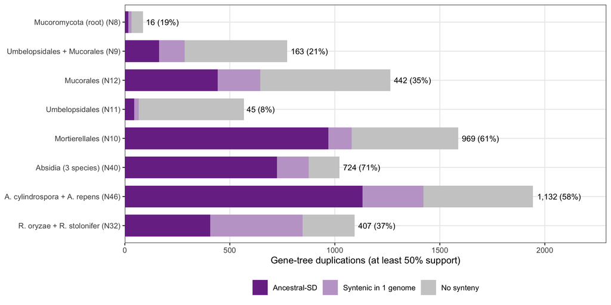

**Figure 6.** Gene-tree duplications on key branches, by synteny class: ancestral-SD (segmental or neighbourhood-syntenic in at least two descendant genomes), syntenic in one genome, or no synteny. Numbers: ancestral-SD duplications and their share. The Absidia and Rhizopus branches carry recent WGDs (Section 5).

```r
bk <- ev_cls[node %in% key_nodes$node, .N, by = .(node, cls)]
bk <- merge(bk, key_nodes, by = "node")
bk[, `:=`(lab = factor(paste0(label, " (", node, ")"), rev(paste0(key_nodes$label, " (", key_nodes$node, ")"))),
          cls = factor(cls, rev(c("ancientSD", "Syntenic in 1 genome", "No synteny")),
                       rev(c("Ancestral-SD", "Syntenic in 1 genome", "No synteny"))))]
bk_tot <- bk[, .(total = sum(N), anc = sum(N[cls == "Ancestral-SD"])), by = lab]
ggplot(bk, aes(N, lab, fill = cls)) +
  geom_col(width = 0.75) +
  geom_text(data = bk_tot, aes(x = total, y = lab, label = sprintf("%s (%.0f%%)", fmt_n(anc), 100 * anc / total)),
            inherit.aes = FALSE, hjust = -0.1, size = 3) +
  scale_fill_manual(values = c("Ancestral-SD" = accent, "Syntenic in 1 genome" = accent_light, "No synteny" = "grey80"),
                    breaks = c("Ancestral-SD", "Syntenic in 1 genome", "No synteny"), name = NULL) +
  scale_x_continuous(expand = expansion(mult = c(0, 0.18))) +
  labs(x = "Gene-tree duplications (at least 50% support)", y = NULL) +
  theme(legend.position = "bottom")
```

```r
stems <- key_nodes[, .(node, stem = paste0(label, " (", node, ")"))]
ac <- anc[node %in% stems$node]
ac_ev <- unique(ac[, .(node, event, cls)])[, .(duplications = .N, ancientSD = sum(cls == "ancientSD")), by = node]
ac_sd <- ac[cls == "ancientSD"]
ac_genes <- ac_sd[, .(genes = uniqueN(c(paste(genome, sub(" .*", "", key)), paste(genome, sub(".* ", "", key)))),
                      genomes = uniqueN(genome), pairs = .N, classified = sum(!is.na(type)),
                      SD = sum(type %in% "SD"), TD = sum(type %in% "TD"), PD = sum(type %in% "PD"),
                      DD = sum(type %in% "DD")), by = node]
anc_counts <- merge(stems, merge(ac_ev, ac_genes, by = "node"), by = "node", sort = FALSE)
anc_counts[, chance := vapply(node, function(nd) 100 * ev_null[node == nd, mean(n_genomes >= 2)], 0)]
anc_counts_show <- anc_counts[, .(
  branch = stem, `supported duplications` = fmt_n(duplications),
  `ancestral-SD duplications` = sprintf("%s (%.0f%%)", fmt_n(ancientSD), 100 * ancientSD / duplications),
  `chance (%)` = sprintf("%.1f", chance),
  `descendant genes` = sprintf("%s (%d genomes)", fmt_n(genes), genomes),
  `copy pairs` = fmt_n(pairs), classified = fmt_n(classified),
  SD = sprintf("%s (%.0f%%)", fmt_n(SD), 100 * SD / classified),
  TD = fmt_n(TD), PD = fmt_n(PD),
  DD = sprintf("%s (%.0f%%)", fmt_n(DD), 100 * DD / classified))]
knitr::kable(anc_counts_show, caption = tcap("anc_counts", "Ancestral-SD duplications on key branches. Supported duplications: OrthoFinder gene-tree duplications on the branch with at least 50% support. Chance: % of duplications classified ancestral-SD after shuffling gene order. Descendant genes: present-day copies descending from the ancestral-SD duplications, summed over genomes. Copy pairs: pairs of copies from the two sides of each duplication within a genome; classified: pairs that doubletrouble classified (the others were not among either gene's top 5 within-genome DIAMOND hits), with their current mode (% of classified pairs)."))
```

Table 3. Ancestral-SD duplications on key branches. Supported duplications: OrthoFinder gene-tree duplications on the branch with at least 50% support. Chance: % of duplications classified ancestral-SD after shuffling gene order. Descendant genes: present-day copies descending from the ancestral-SD duplications, summed over genomes. Copy pairs: pairs of copies from the two sides of each duplication within a genome; classified: pairs that doubletrouble classified (the others were not among either gene’s top 5 within-genome DIAMOND hits), with their current mode (% of classified pairs).

| branch | supported duplications | ancestral-SD duplications | chance (%) | descendant genes | copy pairs | classified | SD | TD | PD | DD |
| --- | --- | --- | --- | --- | --- | --- | --- | --- | --- | --- |
| Mucoromycota (root) (N8) | 86 | 16 (19%) | 0.8 | 2,365 (60 genomes) | 2,237 | 1,921 | 6 (0%) | 3 | 17 | 1,895 (99%) |
| Umbelopsidales + Mucorales (N9) | 773 | 163 (21%) | 1.2 | 17,952 (47 genomes) | 20,121 | 13,132 | 61 (0%) | 141 | 89 | 12,841 (98%) |
| Mucorales (N12) | 1,264 | 442 (35%) | 0.3 | 30,071 (41 genomes) | 19,302 | 17,073 | 149 (1%) | 152 | 92 | 16,680 (98%) |
| Umbelopsidales (N11) | 567 | 45 (8%) | 0.0 | 540 (6 genomes) | 287 | 280 | 6 (2%) | 0 | 0 | 274 (98%) |
| Mortierellales (N10) | 1,588 | 969 (61%) | 0.1 | 25,810 (13 genomes) | 26,342 | 15,019 | 4,346 (29%) | 314 | 384 | 9,975 (66%) |
| Absidia (3 species) (N40) | 1,022 | 724 (71%) | 0.0 | 4,341 (3 genomes) | 2,301 | 2,232 | 872 (39%) | 3 | 0 | 1,357 (61%) |
| A. cylindrospora + A. repens (N46) | 1,943 | 1,132 (58%) | 0.0 | 4,777 (2 genomes) | 2,640 | 2,499 | 1,204 (48%) | 0 | 8 | 1,287 (52%) |
| R. oryzae + R. stolonifer (N32) | 1,094 | 407 (37%) | 0.0 | 1,678 (2 genomes) | 868 | 857 | 375 (44%) | 0 | 0 | 482 (56%) |

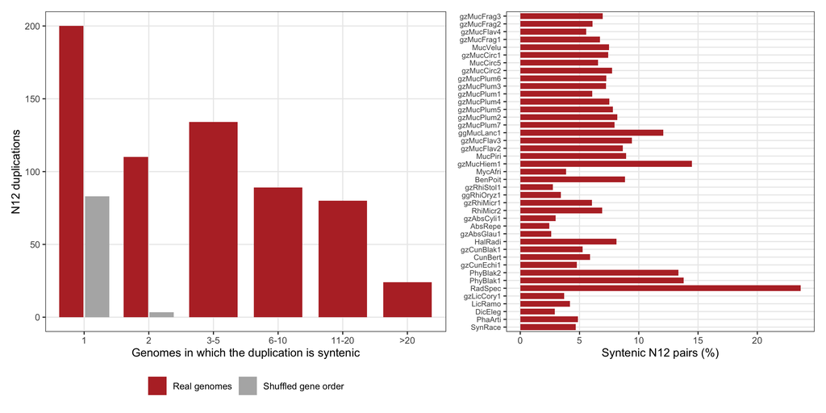

**Figure 7.** Mucorales-stem duplications across Mucorales genomes. Left: number of genomes in which a Mucorales-stem duplication has a neighbourhood-syntenic pair, for the real genomes and with shuffled gene order (mean of 3 shuffles); duplications syntenic in no genome are not shown. Right: neighbourhood-syntenic pairs (%) among the Mucorales-stem duplicates in each Mucorales genome, in species-tree order.

```r
ev12 <- nbx[W == 10 & node == "N12", .(n_genomes = uniqueN(genome[pass])), by = .(event, run)]
ev12[, bin := cut(n_genomes, c(0, 1, 2, 5, 10, 20, Inf), labels = c("1", "2", "3-5", "6-10", "11-20", ">20"))]
evh <- ev12[n_genomes > 0, .N, by = .(bin, real = run == "real")][, N := ifelse(real, N, N / 3)]
evh[, set := factor(ifelse(real, "Real genomes", "Shuffled gene order"), c("Real genomes", "Shuffled gene order"))]
p_ev <- ggplot(evh, aes(bin, N, fill = set)) +
  geom_col(position = position_dodge(width = 0.8), width = 0.75) +
  scale_fill_manual(values = c(order_cols[["Mucorales"]], "grey70"), name = NULL) +
  labs(x = "Genomes in which the duplication is syntenic", y = "N12 duplications") +
  theme(legend.position = "bottom")
g12 <- real10[node == "N12", .(pct = 100 * mean(pass), n = .N), by = genome]
g12[, genome := factor(genome, tip_order)]
p_g <- ggplot(g12, aes(pct, genome)) +
  geom_col(fill = order_cols[["Mucorales"]], width = 0.75) +
  labs(x = "Syntenic N12 pairs (%)", y = NULL) +
  theme(axis.text.y = element_text(size = 6.5))
p_ev + p_g + plot_layout(widths = c(1.3, 1))
```

```r
ac <- function(nd, col) anc_counts[node == nd][[col]]
anc_pct <- function(nd) round(100 * ac(nd, "ancientSD") / ac(nd, "duplications"))
null_anc <- function(nd) 100 * ev_null[node == nd, mean(n_genomes >= 2)]
top_g <- g12[order(-pct)][1:3]
gname <- function(g) gen$species[match(g, gen$genome)]
```

442 of the 1,264 Mucorales-stem duplications (35%; 0.3% expected with shuffled gene order) and 969 of the 1,588 Mortierellales-stem duplications (61%) are ancestral-SD (Figure 6, Table 3). The preceding branch, shared with Umbelopsidales (N9), carries fewer duplications although it is longer (773, of which 21% ancestral-SD; 1.2% expected by chance), and the root of Mucoromycota only 86 (16 ancestral-SD). The Mucorales-stem ancestral-SD duplications have 30,071 descendant genes in 41 genomes; 98% of their classified pairs are dispersed today, against 66% on the Mortierellales stem. The same duplication is often syntenic in some Mucorales genomes and dispersed in the rest; synteny survives best in *Radiomyces spectabilis* (24%), *Mucor hiemalis* (14%), *Phycomyces blakesleeanus* (14%) (Figure 7).

```r
# Blocks of ancestral-SD duplications. Within a genome, two syntenic copy pairs
# of ancestral-SD duplications of the same branch belong to one block if both
# their copies lie within D genes of each other on the same sequences (single
# linkage). Across genomes, duplications of the same branch are merged into one
# ancestral block if their pairs share a block in at least m genomes.
ord_all <- unique(gp[, .(genome, gene = geneID, seq = seqname, start)], by = c("genome", "gene"))
setorder(ord_all, genome, seq, start)
ord_all[, rank := seq_len(.N), by = .(genome, seq)]
bsp <- unique(anc[cls == "ancientSD" & syn == TRUE, .(genome, key, event, node)])
bsp[, c("g1", "g2") := tstrsplit(key, " ", fixed = TRUE)]
bsp <- merge(bsp, ord_all[, .(genome, g1 = gene, s1 = seq, r1 = rank)], by = c("genome", "g1"))
bsp <- merge(bsp, ord_all[, .(genome, g2 = gene, s2 = seq, r2 = rank)], by = c("genome", "g2"))
bsw <- bsp[, s1 > s2 | (s1 == s2 & r1 > r2)]
bsp[bsw, c("s1", "r1", "s2", "r2") := .(s2, r2, s1, r1)]
bsp[, id := .I]
comp_of <- function(n, e1, e2) igraph::components(igraph::graph_from_edgelist(cbind(c(e1, seq_len(n)), c(e2, seq_len(n))), directed = FALSE))$membership
anc_blocks <- function(D, m) {
  q <- bsp[, .(genome, node, s1, s2, i = id, lo1 = r1 - D, hi1 = r1 + D, lo2 = r2 - D, hi2 = r2 + D)]
  j <- bsp[q, on = .(genome, node, s1, s2, r1 >= lo1, r1 <= hi1, r2 >= lo2, r2 <= hi2),
           .(i = i.i, j = x.id), allow.cartesian = TRUE, nomatch = NULL][i < j]
  bk <- copy(bsp)[, block := paste(genome, comp_of(nrow(bsp), j$i, j$j))]
  eb <- unique(bk[, .(event, node, genome, block)])
  ee <- eb[eb, on = .(block, node), .(e1 = event, e2 = i.event, genome), allow.cartesian = TRUE, nomatch = NULL][e1 < e2]
  ee <- ee[, .(n = uniqueN(genome)), by = .(e1, e2)][n >= m]
  ev <- unique(bk[, .(event, node)])
  ev[, ab := comp_of(nrow(ev), match(ee$e1, event), match(ee$e2, event))]
  list(genome_blocks = bk[, .(blocks = uniqueN(block)), by = genome],
       anc = ev[, .(duplications = .N, blocks = uniqueN(ab), single = sum(table(ab) == 1),
                    largest = max(table(ab))), by = node])
}
blk10 <- anc_blocks(10, 1)
blk_alt <- list(D20 = anc_blocks(20, 1)$anc, m2 = anc_blocks(10, 2)$anc)
blk_tab <- merge(key_nodes[, .(node, label)], blk10$anc, by = "node", sort = FALSE)
blk_tab <- merge(blk_tab, blk_alt$D20[, .(node, blocks_D20 = blocks)], by = "node", sort = FALSE)
blk_tab <- merge(blk_tab, blk_alt$m2[, .(node, blocks_m2 = blocks)], by = "node", sort = FALSE)
blk_all <- data.table(node = "", label = "All branches", duplications = sum(blk10$anc$duplications),
                      blocks = sum(blk10$anc$blocks), single = sum(blk10$anc$single), largest = max(blk10$anc$largest),
                      blocks_D20 = sum(blk_alt$D20$blocks), blocks_m2 = sum(blk_alt$m2$blocks))
gb <- merge(blk10$genome_blocks, gen[, .(genome, order = as.character(order))], by = "genome")
gb_ord <- gb[, .(genomes = .N, blocks = sum(blocks), median = median(blocks)), by = order]
bt <- function(nd, col) blk_tab[node == nd][[col]]
```

These duplications fall into far fewer blocks. Grouping duplications of the same branch whose syntenic pairs lie within 10 genes of each other in at least one genome gives 2,607 ancestral blocks for the 5,242 ancestral-SD duplications (2,288-2,953 with a wider distance or when two genomes are required; Table S2). The two stems differ: the 969 Mortierellales-stem duplications form 198 blocks of up to 35 duplications, whereas the 442 Mucorales-stem duplications form 241 blocks, 128 of them with a single duplication. A duplication stands alone when no other ancestral-SD duplication of its branch is kept next to it in any genome, so on old, eroded branches the number of blocks is an upper bound on the number of duplicated segments, not a count of separate events.

```r
# Ancestral-SD duplications by lineage: the order(s) below the branch each duplication is placed on
node_ord <- anc[, .(orders = paste(sort(unique(as.character(gen$order[match(genome, gen$genome)]))), collapse = " + ")), by = node]
lin <- merge(unique(anc[, .(event, node, cls)]), node_ord, by = "node")
recent_wgd <- c("N40", "N46", "N32")
lin[, `:=`(lineage = fifelse(grepl("+", orders, fixed = TRUE), "Shared by several orders", orders),
           branch = fcase(node == "N8", "Root of Mucoromycota (N8)", node == "N9", "Umbelopsidales + Mucorales (N9)",
                          node %in% c("N12", "N10", "N11"), paste0("Stem (", node, ")"),
                          node %in% recent_wgd, "Within the order: Absidia and Rhizopus WGD branches (N40, N46, N32)",
                          orders == "Mucorales", "Within the order: other branches", default = "Within the order"))]
lin_null <- ev_null[, .(anc = sum(n_genomes >= 2)), by = .(node, run)][, .(chance = mean(anc)), by = node]
lin <- merge(lin, lin_null, by = "node", all.x = TRUE)
lin_tot <- lin[cls == "ancientSD", .N]
lin_br <- lin[, .(duplications = .N, aSD = sum(cls == "ancientSD"),
                  chance = sum(unique(data.table(node, chance))$chance, na.rm = TRUE)), by = .(lineage, branch)]
lin_ord <- lin[, .(aSD = sum(cls == "ancientSD")), by = lineage]
lp <- function(l) sprintf("%.0f%%", 100 * lin_ord[lineage == l, aSD] / lin_tot)
```

By lineage, 68% of the ancestral-SD duplications lie within Mucorales, most of them on the branches of the recent *Absidia* and *Rhizopus* WGDs (2,263) rather than on the stem (442); 27% lie within Mortierellales, two thirds of them on its stem; 1% within Umbelopsidales; and only 3% on branches shared by several orders (Table S3).

## 4.5 Which branch? Testing the placement with the gene trees

A gene-tree duplication splits a gene family into two groups of copies, and OrthoFinder places it on the species-tree branch where all species with genes in the two groups last shared an ancestor. A duplication on the Mucorales stem (event 1) leaves Umbelopsidales outside both copy groups. A duplication on the branch shared with Umbelopsidales (event 5) puts Umbelopsidales genes in both copy groups. A Mucorales-stem duplication can still be placed on event 5 if Umbelopsidales lost one copy or if its gene is misplaced in the gene tree: then Umbelopsidales appears in only one copy group (Figure 8).

```r
umb_pre <- paste0(gsub(".", "_", of_names[gen[order == "Umbelopsidales", genome]], fixed = TRUE), "_")
has_umb <- function(x) vapply(strsplit(x, ", ", fixed = TRUE),
                              function(v) any(vapply(umb_pre, function(p) any(startsWith(v, p)), FALSE)), FALSE)
e5 <- sup_int[node == "N9", .(event, s1 = has_umb(genes1), s2 = has_umb(genes2))]
e5[, umb := fifelse(s1 & s2, "both", fifelse(s1 | s2, "one", "absent"))]
e5 <- merge(e5, unique(anc[, .(event, cls)]), by = "event", all.x = TRUE)
e5[is.na(cls), cls := "No synteny"]
syn_umb <- anc[node == "N9" & syn == TRUE, .(syn_in_umb = any(genome %in% gen[order == "Umbelopsidales", genome])), by = event]
e5 <- merge(e5, syn_umb, by = "event", all.x = TRUE)
e5[is.na(syn_in_umb), syn_in_umb := FALSE]
e5_sum <- e5[, .(events = .N, anc = sum(cls == "ancientSD"), anc_syn_umb = sum(cls == "ancientSD" & syn_in_umb)), by = umb]
e1 <- data.table(umb = "stem", events = ac("N12", "duplications"), anc = ac("N12", "ancientSD"))
e5s <- function(u, col) e5_sum[umb == u][[col]]
```

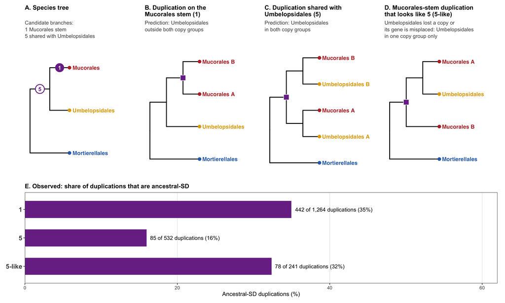

**Figure 8.** How the gene trees place a duplication, and the test of event 5. Top left: the species tree with the two candidate branches. Top, other panels: cartoon gene trees for one gene family (A, B: the two copies; red square: the duplication) as predicted for a duplication on the Mucorales stem (event 1), for a duplication on the branch shared with Umbelopsidales (event 5), and for a Mucorales-stem duplication that ends up on event 5 because Umbelopsidales lost a copy or its gene is misplaced. Bottom: observed share of ancestral-SD duplications among the event-1 duplications (1), the event-5 duplications with Umbelopsidales in both copy groups (5) and those with Umbelopsidales in only one copy group (5-like).

```r
ord_col3 <- c(Mortierellales = order_cols[["Mortierellales"]], Umbelopsidales = order_cols[["Umbelopsidales"]],
              Mucorales = order_cols[["Mucorales"]])
cartoon <- function(nwk, dup_tips = NULL, title, pred, events = NULL) {
  tr <- read.tree(text = nwk)
  tr$tip.label <- gsub("_", " ", tr$tip.label)
  tips <- data.frame(label = tr$tip.label,
                     ord = sub(" .*", "", tr$tip.label))
  p <- ggtree(tr, branch.length = "none", linewidth = 0.7) %<+% tips
  d <- p$data
  p <- p + geom_tiplab(aes(colour = ord), offset = 0.15, size = 3.3, fontface = "bold") +
    geom_tippoint(aes(colour = ord), size = 2.2) +
    scale_colour_manual(values = ord_col3, guide = "none") +
    labs(title = title, subtitle = pred) +
    coord_cartesian(xlim = c(0, max(d$x) + 3.2), clip = "off") +
    theme(plot.title = element_text(size = 10.5, face = "bold"),
          plot.subtitle = element_text(size = 9, colour = "grey30", lineheight = 1.05),
          plot.margin = margin(4, 8, 4, 4))
  if (!is.null(dup_tips)) {
    dn <- getMRCA(tr, gsub("_", " ", dup_tips))
    p <- p + geom_point(data = d[d$node == dn, ], aes(x, y), shape = 22, size = 4.5, fill = accent, colour = "white")
  }
  if (!is.null(events)) {
    ev_d <- merge(d, events, by = "label")
    p <- p + geom_point(data = ev_d, aes(branch, y), shape = 21, size = 6.5, fill = accent, colour = accent) +
      geom_text(data = ev_d, aes(branch, y, label = id), colour = "white", fontface = "bold", size = 3.3)
  }
  p
}
sp_tr <- "(Mortierellales,(Umbelopsidales,Mucorales));"
p_sp <- cartoon(sp_tr, title = "A. Species tree", pred = "Candidate branches:\n1 Mucorales stem\n5 shared with Umbelopsidales")
sp_d <- p_sp$data
umbmuc <- sp_d[sp_d$node == getMRCA(read.tree(text = sp_tr), c("Umbelopsidales", "Mucorales")), ]
p_sp <- p_sp +
  geom_point(data = umbmuc, aes(branch, y), shape = 21, size = 6.5, fill = "white", colour = accent, stroke = 1) +
  geom_text(data = umbmuc, aes(branch, y), label = "5", colour = accent, fontface = "bold", size = 3.3) +
  geom_point(data = sp_d[sp_d$label %in% "Mucorales", ], aes(branch, y), shape = 21, size = 6.5, fill = accent, colour = accent) +
  geom_text(data = sp_d[sp_d$label %in% "Mucorales", ], aes(branch, y), label = "1", colour = "white", fontface = "bold", size = 3.3)
p_e1 <- cartoon("(Mortierellales,(Umbelopsidales,(Mucorales_A,Mucorales_B)));", c("Mucorales_A", "Mucorales_B"),
                "B. Duplication on the\nMucorales stem (1)", "Prediction: Umbelopsidales\noutside both copy groups\n")
p_e5 <- cartoon("(Mortierellales,((Umbelopsidales_A,Mucorales_A),(Umbelopsidales_B,Mucorales_B)));",
                c("Umbelopsidales_A", "Mucorales_A", "Umbelopsidales_B", "Mucorales_B"),
                "C. Duplication shared with\nUmbelopsidales (5)", "Prediction: Umbelopsidales\nin both copy groups\n")
p_mis <- cartoon("(Mortierellales,((Umbelopsidales,Mucorales_A),Mucorales_B));",
                 c("Umbelopsidales", "Mucorales_A", "Mucorales_B"),
                 "D. Mucorales-stem duplication\nthat looks like 5 (5-like)", "Umbelopsidales lost a copy or\nits gene is misplaced: Umbelopsidales\nin one copy group only")
obs <- rbind(
  data.table(group = "1", events = e1$events, anc = e1$anc),
  data.table(group = "5", events = e5s("both", "events"), anc = e5s("both", "anc")),
  data.table(group = "5-like", events = e5s("one", "events"), anc = e5s("one", "anc")))
obs[, `:=`(pct = 100 * anc / events, group = factor(group, rev(group)))]
p_obs <- ggplot(obs, aes(pct, group)) +
  geom_col(fill = accent, width = 0.6) +
  geom_text(aes(label = sprintf("%s of %s duplications (%.0f%%)", fmt_n(anc), fmt_n(events), pct)),
            hjust = -0.05, size = 3.3) +
  scale_x_continuous(limits = c(0, 62), expand = c(0, 0)) +
  labs(x = "Ancestral-SD duplications (%)", y = NULL, title = "E. Observed: share of duplications that are ancestral-SD") +
  theme(axis.text.y = element_text(size = 11, face = "bold")) +
  theme(plot.title = element_text(size = 10.5, face = "bold"), panel.grid.major.y = element_blank())
(p_sp | p_e1 | p_e5 | p_mis) / p_obs + plot_layout(heights = c(1.5, 1))
```

532 of the 773 duplications placed on event 5 have Umbelopsidales genes in both copy groups and are therefore shared with Umbelopsidales; 85 of them (16%) are ancestral-SD, 34 with synteny in Umbelopsidales genomes. The other 241 have Umbelopsidales in only one copy group, and 78 of them (32%) are ancestral-SD, all syntenic only in Mucorales genomes: the same share as on the Mucorales stem (35%), so these are most likely Mucorales-stem block duplications placed one branch too deep. The block signal shared with Umbelopsidales is thus about half as strong per duplication as that of the Mucorales stem.

# 5 Ks of segmental and ancestral-segmental duplicates

Ks grows with the age of a duplicate pair until it saturates at about 2. A large-scale duplication leaves many pairs of the same age, a peak in the Ks distribution, as long as it is younger than saturation.

```r
ksd <- pairs[!near_ident & Ks <= 5]
ksd[, class := fifelse(type == "SD", "Segmental (SD)", "Small-scale (TD, PD, DD)")]
ksd <- merge(ksd, gen[, .(genome, genes, order)], by = "genome")
```

Peaks were fitted with Gaussian mixture models on log Ks (Ks 0.05-5, 1-4 components chosen by BIC) for genomes with at least 100 segmental pairs, so that the saturated pairs form their own component (Table 4). To see how far back Ks carries age information, Ks was computed in the same way for 400 random one-to-one orthologs of species pairs with splits of different ages on the dated tree (Table 5, Figure 9B). It is not used to place events on branches: near saturation, the small differences between paralog and ortholog Ks cannot order a duplication and a speciation, and the branch of each event comes from the gene trees and shared synteny.

```r
fit_peaks <- function(ks) {
  m <- densityMclust(log(ks), G = 1:4, modelNames = "V", verbose = FALSE, plot = FALSE)
  o <- order(m$parameters$mean)
  data.table(component = seq_along(o), mean_log = m$parameters$mean[o],
             sd_log = sqrt(m$parameters$variance$sigmasq[o]), weight = m$parameters$pro[o])
}
sd_n <- ksd[class == "Segmental (SD)", .N, by = genome]
peak_genomes <- intersect(tip_order, sd_n[N >= 100, genome])
peaks <- rbindlist(lapply(peak_genomes, function(g) {
  fit_peaks(ksd[genome == g & class == "Segmental (SD)", Ks])[, genome := g]
}))
peaks[, Ks := exp(mean_log)]
# The main sub-saturation peak: the largest component with mean Ks < 2
main_peak <- peaks[Ks < 2][order(-weight)][, .SD[1], by = genome]
peak_tab <- peaks[, .(components = paste(sprintf("%.2f (%.0f%%)", Ks, 100 * weight), collapse = ", ")),
                  by = genome]
peak_tab <- merge(peak_tab, sd_n, by = "genome")
peak_tab <- merge(peak_tab, main_peak[, .(genome, main_Ks = round(Ks, 2), main_weight = round(weight, 2))],
                  by = "genome", all.x = TRUE)
peak_tab <- merge(gen[, .(genome, order)], peak_tab, by = "genome")[order(order, -main_weight)]
knitr::kable(peak_tab[, .(genome, order, SD_pairs = N, components, main_Ks, main_weight)],
             caption = tcap("peaks", "Gaussian mixture components of the log-Ks distribution of segmental pairs (Ks 0.05-5): component mean Ks and weight. main_Ks and main_weight: the largest component with mean Ks < 2."))
```

Table 4. Gaussian mixture components of the log-Ks distribution of segmental pairs (Ks 0.05-5): component mean Ks and weight. main_Ks and main_weight: the largest component with mean Ks < 2.

| genome | order | SD_pairs | components | main_Ks | main_weight |
| --- | --- | --- | --- | --- | --- |
| LinSchm | Mortierellales | 744 | 1.69 (32%), 3.72 (28%), 4.41 (40%) | 1.69 | 0.32 |
| gzMorAlpi1 | Mortierellales | 625 | 1.63 (26%), 3.92 (36%), 4.46 (38%) | 1.63 | 0.26 |
| LinElon | Mortierellales | 685 | 0.25 (12%), 2.12 (24%), 3.87 (35%), 4.41 (29%) | 0.25 | 0.12 |
| MorAlpi2 | Mortierellales | 653 | 0.59 (10%), 2.45 (21%), 3.93 (36%), 4.50 (33%) | 0.59 | 0.10 |
| LinHyal2 | Mortierellales | 717 | 0.49 (8%), 2.10 (20%), 3.61 (23%), 4.33 (49%) | 0.49 | 0.08 |
| EntParv2 | Mortierellales | 398 | 0.29 (7%), 2.16 (19%), 3.81 (26%), 4.45 (48%) | 0.29 | 0.07 |
| LinAmoe | Mortierellales | 603 | 0.64 (7%), 2.27 (20%), 3.83 (34%), 4.37 (39%) | 0.64 | 0.07 |
| gzLinHyal1 | Mortierellales | 758 | 0.45 (7%), 2.32 (26%), 3.82 (29%), 4.40 (38%) | 0.45 | 0.07 |
| gzPodHuml1 | Mortierellales | 534 | 0.48 (7%), 2.27 (30%), 4.11 (63%) | 0.48 | 0.07 |
| ggMorZona1 | Mortierellales | 740 | 0.38 (6%), 2.27 (26%), 3.97 (38%), 4.52 (29%) | 0.38 | 0.06 |
| EntParv | Mortierellales | 400 | 0.34 (5%), 2.48 (27%), 4.22 (54%), 4.74 (13%) | 0.34 | 0.05 |
| MorAlpi3 | Mortierellales | 512 | 0.36 (4%), 2.37 (21%), 3.85 (36%), 4.39 (38%) | 0.36 | 0.04 |
| gzDisGlob2 | Mortierellales | 395 | 0.22 (4%), 2.20 (31%), 3.88 (29%), 4.49 (36%) | 0.22 | 0.04 |
| AbsRepe | Mucorales | 1302 | 0.46 (17%), 1.71 (69%), 3.90 (14%) | 1.71 | 0.69 |
| gzAbsGlau1 | Mucorales | 497 | 0.57 (11%), 1.91 (69%), 4.11 (21%) | 1.91 | 0.69 |
| ggRhiOryz1 | Mucorales | 1276 | 0.54 (20%), 1.63 (63%), 3.76 (17%) | 1.63 | 0.63 |
| gzRhiStol1 | Mucorales | 318 | 0.25 (12%), 1.98 (54%), 3.99 (34%) | 1.98 | 0.54 |
| gzAbsCyli1 | Mucorales | 1527 | 0.44 (15%), 1.64 (21%), 1.75 (53%), 3.96 (10%) | 1.75 | 0.53 |
| LicRamo | Mucorales | 124 | 1.28 (45%), 4.10 (55%) | 1.28 | 0.45 |
| gzLicCory1 | Mucorales | 145 | 0.47 (14%), 2.07 (48%), 4.16 (38%) | 0.47 | 0.14 |
| RadSpec | Mucorales | 134 | 0.71 (3%), 2.75 (41%), 4.29 (56%) | 0.71 | 0.03 |

```r
orth_pairs <- data.table(
  a = c("gzAbsCyli1", "AbsRepe", "AbsRepe", "ggRhiOryz1", "ggRhiOryz1", "AbsRepe",
        "ggMorZona1", "ggRhiOryz1", "ggRhiOryz1",
        "ggMorZona1", "ggMorZona1", "ggMorZona1", "gzMorAlpi1", "ggMorZona1",
        "gzMucCirc1", "gzMucCirc1", "gzMucCirc1",
        # splits at ages 70-190, to fill the gap in Ks against split age
        "gzMucFrag1", "UmbIsab2", "EntParv", "gzMucFrag1", "LicRamo", "gzCunBlak1",
        "gzMucFrag1", "gzMucFlav2"),
  b = c("AbsRepe", "gzAbsGlau1", "HalRadi", "gzRhiStol1", "gzRhiMicr1", "ggRhiOryz1",
        "gzPodHuml1", "gzUmbVina1", "ggMorZona1",
        "gzLinHyal1", "LinElon", "LinSchm", "gzDisGlob2", "gzMorAlpi1",
        "gzMucHiem1", "BenPoit", "ggRhiOryz1",
        "MucVelu", "gzUmbIsab1", "EntParv2", "gzMucCirc1", "gzLicCory1", "gzCunEchi1",
        "gzMucPlum1", "MucPiri"),
  split = c("Within Absidia (A. cylindrospora / A. repens)", "Within Absidia (A. repens / A. glauca)",
            "Absidia / Halteromyces", "Within Rhizopus (R. oryzae / R. stolonifer)",
            "Within Rhizopus (R. oryzae / R. microsporus)", "Absidia / Rhizopus",
            "Mortierellales crown", "Mucorales / Umbelopsidales", "Mucorales / Mortierellales",
            "Within Mortierellales (M. zonata / L. hyalina)", "Within Mortierellales (M. zonata / L. elongata)",
            "Within Mortierellales (M. zonata / L. schmuckeri)", "Within Mortierellales (M. alpina / D. globulifera)",
            "Within Mortierellales (M. zonata / M. alpina)", "Within Mucoraceae (M. circinelloides / M. hiemalis)",
            "Within Mucoraceae (M. circinelloides / B. poitrasii)", "Mucor / Rhizopus",
            "Within Mucor (M. fragilis / M. velutinosus)", "Within Umbelopsis (U. isabellina strains)",
            "Within Mortierellales (E. parvispora strains)", "Within Mucor (M. fragilis / M. circinelloides)",
            "Within Lichtheimia (L. ramosa / L. corymbifera)", "Within Cunninghamella (C. blakesleeana / C. echinulata)",
            "Within Mucor (M. fragilis / M. plumbeus)", "Within Mucor (M. flavus / M. piriformis)"))
# Age of each split on the dated tree (relative time, root = 1,000)
orth_pairs[, age := round(max(node.depth.edgelength(tree)) -
                            node.depth.edgelength(tree)[getMRCA(tree, c(a, b))]), by = .(a, b)]

orth_path <- "data/genome_duplication/ortholog_ks.tsv"
# Computed once per species pair and cached; only pairs missing from the cache are computed
orth_done <- if (file.exists(orth_path)) unique(fread(orth_path)[, paste(a, b)]) else character()
orth_todo <- orth_pairs[!paste(a, b) %in% orth_done]
if (nrow(orth_todo) > 0) {
  load_cds <- function(g) {
    f <- sprintf("data/doubletrouble/input_data/%s_data.rds", gen[genome == g, dt_id])
    fetch(f)
    cds <- readRDS(f)$cds
    cds[Biostrings::width(cds) %% 3 == 0]  # as in pairs2kaks()
  }
  load_alias <- function(g) {  # any OrthoFinder identifier -> gene ID
    f <- sprintf("data/genomes/%1$s/%1$s_IDtbl.tsv", g)
    fetch(f)
    ids <- fread(f)
    unique(rbind(ids[, .(id = proteinID, gene = geneID)], ids[, .(id = rnaID, gene = geneID)],
                 ids[, .(id = geneID, gene = geneID)]))
  }
  # OrthoFinder separates genes with ", "; public FASTA headers carry descriptions,
  # so take the first word of each element that is a known identifier.
  known_id <- function(cell, known) {
    vapply(strsplit(cell, ", ", fixed = TRUE), function(p) {
      w <- sub(" .*", "", p); w <- w[w %in% known]
      if (length(w) == 1) w else NA_character_
    }, "")
  }
  n_genes_in <- function(cell) lengths(strsplit(cell, ", ", fixed = TRUE))
  ks_of_pairs <- function(cds_a, cds_b, ga, gb) {
    seqs <- c(cds_a[ga], cds_b[gb])
    names(seqs) <- c(paste0("a_", ga), paste0("b_", gb))
    idx <- lapply(seq_along(ga), function(i) c(i, length(ga) + i))
    r <- MSA2dist::indices2kaks(cds = seqs, indices = idx, model = "MYN", isMSA = FALSE,
                                threads = max(1, parallel::detectCores() - 1), verbose = FALSE)
    as.numeric(ifelse(r$Ks == "NA", NA, r$Ks))
  }
  ortholog_ks <- function(a, b, n = 400, seed = 1) {
    f <- sprintf("data/orthofinder/results/Orthologues/Orthologues_%1$s/%1$s__v__%2$s.tsv",
                 of_names[[a]], of_names[[b]])
    fetch(f)
    o <- fread(f, sep = "\t", header = TRUE, quote = "", col.names = c("og", "a", "b"))
    alias_a <- load_alias(a); alias_b <- load_alias(b)
    one <- o[n_genes_in(a) == 1 & n_genes_in(b) == 1]
    one[, `:=`(gene_a = alias_a$gene[match(known_id(a, alias_a$id), alias_a$id)],
               gene_b = alias_b$gene[match(known_id(b, alias_b$id), alias_b$id)])]
    cds_a <- load_cds(a); cds_b <- load_cds(b)
    one <- one[gene_a %in% names(cds_a) & gene_b %in% names(cds_b)]
    set.seed(seed)
    s <- one[sample(.N, min(n, .N))]
    data.table(a = a, b = b, one_to_one = nrow(one), gene_a = s$gene_a, gene_b = s$gene_b,
               Ks = ks_of_pairs(cds_a, cds_b, s$gene_a, s$gene_b))
  }
  orth_new <- rbindlist(lapply(seq_len(nrow(orth_todo)), function(i) {
    ortholog_ks(orth_todo$a[i], orth_todo$b[i])
  }))
  fwrite(rbind(if (file.exists(orth_path)) fread(orth_path) else NULL, orth_new), orth_path, sep = "\t")
}
orth_ks <- fread(orth_path)
orth_ks <- merge(orth_ks, orth_pairs, by = c("a", "b"))
orth_sum <- orth_ks[, .(age = age[1], one_to_one = one_to_one[1], sampled = .N,
                        Ks_q25 = quantile(Ks, 0.25, na.rm = TRUE), Ks_median = median(Ks, na.rm = TRUE),
                        Ks_q75 = quantile(Ks, 0.75, na.rm = TRUE),
                        saturated_pct = 100 * mean(Ks > 2, na.rm = TRUE)), by = .(split, a, b)]
# Peak of each ortholog distribution, fitted as for the paralogs (largest
# Gaussian component below Ks 3): near saturation the median is pulled up by
# saturated orthologs, so the peak is the value to compare with paralog peaks
orth_peak <- orth_ks[!is.na(Ks) & Ks >= 0.05 & Ks <= 5, {
  pk <- fit_peaks(Ks)[, Ks := exp(mean_log)][Ks < 3][order(-weight)]
  # reported only if this component holds at least half of the orthologs;
  # otherwise the distribution is mostly saturated and the peak is not a speciation
  if (nrow(pk) > 0 && pk$weight[1] >= 0.5) .(Ks_peak = pk$Ks[1], peak_weight = pk$weight[1])
  else .(Ks_peak = NA_real_, peak_weight = if (nrow(pk) > 0) pk$weight[1] else 0)
}, by = split]
orth_sum <- merge(orth_sum, orth_peak, by = "split")
orth_sum <- orth_sum[match(orth_pairs$split, split)]
orth_sum[, peak_weight := NULL]
setcolorder(orth_sum, c("split", "a", "b", "age", "one_to_one", "sampled", "Ks_peak"))
num <- c("Ks_q25", "Ks_median", "Ks_q75", "saturated_pct", "Ks_peak")
orth_sum[, (num) := lapply(.SD, round, 2), .SDcols = num]
local({ op <- options(knitr.kable.NA = ""); on.exit(options(op)); knitr::kable(orth_sum, caption = tcap("orthks", paste0("Ks between one-to-one orthologs of species pairs (400 random orthologs per pair; MYN model, as for the paralogs). age: age of the split on the dated tree (relative time, root = 1,000). Ks_peak: largest Gaussian mixture component below Ks 3, fitted as for the paralogs (", tab("peaks"), "), given only where it holds at least half of the orthologs; empty where the distribution is mostly saturated. one_to_one: number of one-to-one orthologs available. saturated_pct: percentage of orthologs with Ks > 2.")))})
```

Table 5. Ks between one-to-one orthologs of species pairs (400 random orthologs per pair; MYN model, as for the paralogs). age: age of the split on the dated tree (relative time, root = 1,000). Ks_peak: largest Gaussian mixture component below Ks 3, fitted as for the paralogs (Table 4), given only where it holds at least half of the orthologs; empty where the distribution is mostly saturated. one_to_one: number of one-to-one orthologs available. saturated_pct: percentage of orthologs with Ks > 2.

| split | a | b | age | one_to_one | sampled | Ks_peak | Ks_q25 | Ks_median | Ks_q75 | saturated_pct |
| --- | --- | --- | --- | --- | --- | --- | --- | --- | --- | --- |
| Within Absidia (A. cylindrospora / A. repens) | gzAbsCyli1 | AbsRepe | 47 | 10793 | 400 | 0.25 | 0.21 | 0.26 | 0.33 | 0.50 |
| Within Absidia (A. repens / A. glauca) | AbsRepe | gzAbsGlau1 | 195 | 7200 | 400 | 1.96 | 1.69 | 2.25 | 3.83 | 58.15 |
| Absidia / Halteromyces | AbsRepe | HalRadi | 246 | 5645 | 400 |  | 2.08 | 3.35 | 4.04 | 78.25 |
| Within Rhizopus (R. oryzae / R. stolonifer) | ggRhiOryz1 | gzRhiStol1 | 194 | 7330 | 400 | 1.76 | 1.54 | 2.12 | 3.38 | 51.91 |
| Within Rhizopus (R. oryzae / R. microsporus) | ggRhiOryz1 | gzRhiMicr1 | 259 | 5666 | 400 | 1.93 | 1.75 | 2.65 | 3.95 | 66.42 |
| Absidia / Rhizopus | AbsRepe | ggRhiOryz1 | 537 | 3234 | 400 |  | 3.52 | 3.88 | 4.34 | 96.25 |
| Mortierellales crown | ggMorZona1 | gzPodHuml1 | 280 | 7271 | 400 |  | 3.28 | 4.14 | 4.58 | 89.70 |
| Mucorales / Umbelopsidales | ggRhiOryz1 | gzUmbVina1 | 748 | 3422 | 400 |  | 3.56 | 3.99 | 4.36 | 98.99 |
| Mucorales / Mortierellales | ggRhiOryz1 | ggMorZona1 | 1000 | 2408 | 400 |  | 3.61 | 4.03 | 4.40 | 99.25 |
| Within Mortierellales (M. zonata / L. hyalina) | ggMorZona1 | gzLinHyal1 | 19 | 10436 | 400 | 0.12 | 0.10 | 0.12 | 0.15 | 0.50 |
| Within Mortierellales (M. zonata / L. elongata) | ggMorZona1 | LinElon | 41 | 9426 | 400 | 0.25 | 0.21 | 0.25 | 0.32 | 0.50 |
| Within Mortierellales (M. zonata / L. schmuckeri) | ggMorZona1 | LinSchm | 68 | 9689 | 400 | 0.48 | 0.39 | 0.50 | 0.69 | 2.26 |
| Within Mortierellales (M. alpina / D. globulifera) | gzMorAlpi1 | gzDisGlob2 | 222 | 7245 | 400 |  | 2.35 | 3.79 | 4.44 | 82.25 |
| Within Mortierellales (M. zonata / M. alpina) | ggMorZona1 | gzMorAlpi1 | 238 | 7606 | 400 |  | 2.70 | 4.02 | 4.48 | 87.50 |
| Within Mucoraceae (M. circinelloides / M. hiemalis) | gzMucCirc1 | gzMucHiem1 | 293 | 8588 | 400 |  | 3.30 | 3.96 | 4.30 | 86.73 |
| Within Mucoraceae (M. circinelloides / B. poitrasii) | gzMucCirc1 | BenPoit | 343 | 8006 | 400 |  | 3.27 | 3.95 | 4.30 | 88.16 |
| Mucor / Rhizopus | gzMucCirc1 | ggRhiOryz1 | 396 | 5377 | 400 |  | 3.39 | 3.97 | 4.34 | 93.00 |
| Within Mucor (M. fragilis / M. velutinosus) | gzMucFrag1 | MucVelu | 71 | 9984 | 400 | 0.42 | 0.33 | 0.43 | 0.56 | 1.01 |
| Within Umbelopsis (U. isabellina strains) | UmbIsab2 | gzUmbIsab1 | 76 | 7844 | 400 | 0.39 | 0.31 | 0.38 | 0.48 | 0.50 |
| Within Mortierellales (E. parvispora strains) | EntParv | EntParv2 | 81 | 8773 | 400 | 0.77 | 0.58 | 0.75 | 0.97 | 2.75 |
| Within Mucor (M. fragilis / M. circinelloides) | gzMucFrag1 | gzMucCirc1 | 85 | 9943 | 400 | 0.69 | 0.51 | 0.68 | 0.98 | 2.54 |
| Within Lichtheimia (L. ramosa / L. corymbifera) | LicRamo | gzLicCory1 | 87 | 9546 | 400 | 0.56 | 0.45 | 0.59 | 0.74 | 1.50 |
| Within Cunninghamella (C. blakesleeana / C. echinulata) | gzCunBlak1 | gzCunEchi1 | 122 | 8199 | 400 | 1.86 | 1.65 | 2.22 | 3.41 | 56.15 |
| Within Mucor (M. fragilis / M. plumbeus) | gzMucFrag1 | gzMucPlum1 | 147 | 8733 | 400 | 1.43 | 1.26 | 1.69 | 2.91 | 39.49 |
| Within Mucor (M. flavus / M. piriformis) | gzMucFlav2 | MucPiri | 175 | 8287 | 400 |  | 1.82 | 3.26 | 4.22 | 68.97 |

```r
nb_real10 <- nb[W == 10 & !is_null, .(genome, key, nb_pass = pass)]
anc <- merge(cross[, .(genome, key, node, event, type)], nb_real10, by = c("genome", "key"), all.x = TRUE)
pair_ks <- unique(pairs[, .(genome, key = paste(pmin(dup1, dup2), pmax(dup1, dup2)), Ks)], by = c("genome", "key"))
anc <- merge(anc, pair_ks, by = c("genome", "key"), all.x = TRUE)
# segmental pairs count only if not near-identical, as in the neighbourhood test
anc[, syn := (type %in% "SD" & !is.na(Ks) & Ks >= 0.05) | (!is.na(nb_pass) & nb_pass)]
anc <- merge(anc, anc[, .(syn_genomes = uniqueN(genome[syn])), by = event], by = "event")
anc[, cls := fcase(syn_genomes >= 2, "ancientSD", syn_genomes == 1, "Syntenic in 1 genome",
                   default = "No synteny")]
anc_nodes <- key_nodes[node != "N8"]
anc_ev <- unique(anc[, .(event, node, cls)])[node %in% anc_nodes$node,
  .(events = .N, ancientSD = sum(cls == "ancientSD")), by = node]
ksw <- anc[node %in% anc_nodes$node & !is.na(Ks) & Ks >= 0.05 & Ks <= 5]
ksw[, set := fifelse(cls == "ancientSD", "ancientSD", "other")]
anc_ks <- ksw[, .(pairs = .N, median_Ks = median(Ks), below2 = 100 * mean(Ks < 2),
                  window = 100 * mean(Ks > 1.5 & Ks < 2.6)), by = .(node, set)]
anc_ks_w <- dcast(anc_ks, node ~ set, value.var = c("pairs", "median_Ks", "below2", "window"))
anc_tab <- merge(anc_nodes, merge(anc_ev, anc_ks_w, by = "node"), by = "node", sort = FALSE)
anc_show <- anc_tab[, .(node, label, events, ancientSD_pct = round(100 * ancientSD / events),
                        ancientSD_pairs = pairs_ancientSD, median_Ks = round(median_Ks_ancientSD, 2),
                        Ks_below_2 = round(below2_ancientSD, 1),
                        Ks_1.5_2.6 = round(window_ancientSD, 1), Ks_1.5_2.6_other = round(window_other, 1))]
knitr::kable(anc_show, caption = tcap("anc", "Gene-tree duplications that are ancestral-SD (segmental or neighbourhood-syntenic in at least two descendant genomes) on key branches, and the Ks of their duplicate pairs (Ks 0.05-5). Ks_below_2: % of ancestral-SD pairs with Ks < 2; Ks_1.5_2.6: % between Ks 1.5 and 2.6 (the Mortierellales Ks component), for ancestral-SD pairs and for the other pairs of the same branch."))
```

Table 6. Gene-tree duplications that are ancestral-SD (segmental or neighbourhood-syntenic in at least two descendant genomes) on key branches, and the Ks of their duplicate pairs (Ks 0.05-5). Ks_below_2: % of ancestral-SD pairs with Ks < 2; Ks_1.5_2.6: % between Ks 1.5 and 2.6 (the Mortierellales Ks component), for ancestral-SD pairs and for the other pairs of the same branch.

| node | label | events | ancientSD_pct | ancientSD_pairs | median_Ks | Ks_below_2 | Ks_1.5_2.6 | Ks_1.5_2.6_other |
| --- | --- | --- | --- | --- | --- | --- | --- | --- |
| N9 | Umbelopsidales + Mucorales | 773 | 21 | 12915 | 4.02 | 2.0 | 4.5 | 4.5 |
| N12 | Mucorales | 1264 | 35 | 16395 | 4.06 | 2.4 | 4.6 | 3.8 |
| N11 | Umbelopsidales | 567 | 8 | 262 | 4.17 | 3.1 | 1.5 | 6.3 |
| N10 | Mortierellales | 1588 | 61 | 13992 | 4.12 | 6.1 | 11.1 | 5.7 |
| N40 | Absidia (3 species) | 1022 | 71 | 2209 | 1.92 | 54.0 | 50.0 | 36.3 |
| N46 | A. cylindrospora + A. repens | 1943 | 58 | 2493 | 1.63 | 68.1 | 42.2 | 30.0 |
| N32 | R. oryzae + R. stolonifer | 1094 | 37 | 855 | 2.28 | 41.1 | 37.1 | 34.0 |

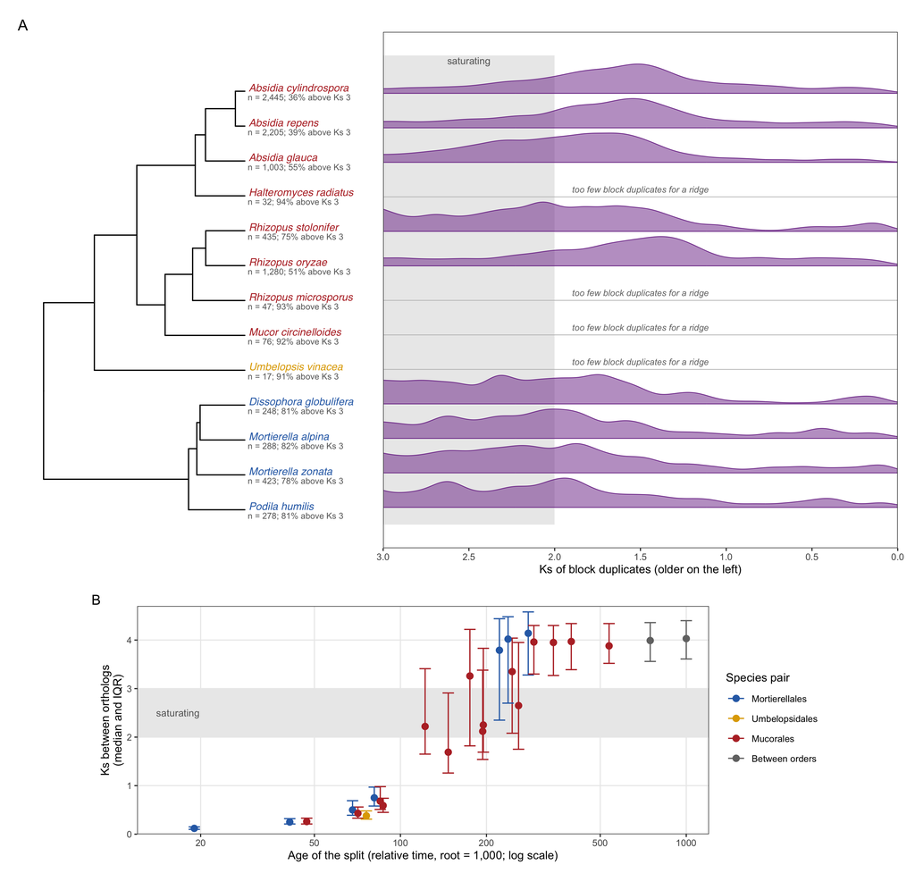

**Figure 9.** (A) Ks of block duplicates (segmental by doubletrouble, or ancestral-SD) in genomes with a Ks signal and in reference genomes without one, beside the dated species tree pruned to these genomes. Each ridge is the Ks density between 0 and 3, scaled to its own maximum, with the Ks axis reversed so that older duplicates lie to the left, as in the tree; n (under each name): block duplicate pairs in this range, with the share of the genome’s block duplicates beyond Ks 3, where Ks carries no age information. Genomes with fewer than 100 such pairs get no ridge. Shaded: Ks 2-3, where Ks starts to saturate. The ridges show where a genome has a burst of block duplicates and how old it is relative to the other duplicates of the same genome, which share its substitution rate and codon usage. They do not place events on branches of the tree: at these Ks, WGD peaks and the nearest speciations cannot be ordered (Table 5), and the branch of each event comes from the gene trees and shared synteny (Figure 6, Figure 8). (B) Where Ks saturates: Ks of one-to-one orthologs against the age of the split on the dated tree (relative time, root = 1,000; log scale) for the species pairs of Table 5, with the median and interquartile range of 400 orthologs per pair, coloured by the order the pair belongs to. Ks rises with split age, reaches about 2 between ages 120 and 200 depending on the lineage, and levels off near 4 whatever the age, so Ks above about 2-3 (shaded, as in A) carries little or no age information. The dated tree has no Mortierellales splits between ages 90 and 220.

```r
ridge_genomes <- c("gzPodHuml1", "ggMorZona1", "gzMorAlpi1", "gzDisGlob2", "gzUmbVina1",
                   "gzMucCirc1", "gzRhiMicr1", "gzRhiStol1", "ggRhiOryz1",
                   "HalRadi", "gzAbsGlau1", "gzAbsCyli1", "AbsRepe")
rtree <- keep.tip(tree, ridge_genomes)
rtip <- data.frame(label = ridge_genomes, sp = gen$species[match(ridge_genomes, gen$genome)],
                   order = gen$order[match(ridge_genomes, gen$genome)])
p_rt <- ggtree(rtree, ladderize = TRUE) %<+% rtip
rd <- as.data.table(p_rt$data)[isTip == TRUE, .(genome = label, y)]
ytop <- max(rd$y) + 1.1
# Block duplicates: segmental pairs and pairs of ancestral-SD duplications (Ks 0.05-5)
anc_set <- unique(anc[cls == "ancientSD", paste(genome, key)])
blk <- pairs[genome %in% ridge_genomes & near_ident == FALSE & !is.na(Ks),
             .(genome, key = paste(pmin(dup1, dup2), pmax(dup1, dup2)), type, Ks)]
blk <- unique(blk[type == "SD" | paste(genome, key) %in% anc_set], by = c("genome", "key"))
blk_n <- blk[, .(n = sum(Ks <= 3), sat = 100 * mean(Ks > 3)), by = genome]
blk_n <- merge(data.table(genome = ridge_genomes), blk_n, by = "genome", all.x = TRUE)
blk_n[is.na(n), `:=`(n = 0L, sat = 0)]
blk_n <- merge(blk_n, rd, by = "genome")
min_pairs <- 100
# Ridge per genome: density of block-duplicate Ks on 0-3, scaled to its own maximum
rid <- blk[genome %in% blk_n[n >= min_pairs, genome] & Ks <= 3.5, {
  de <- density(Ks, bw = 0.08, from = 0, to = 3.5, n = 400)
  .(ks = de$x, dens = de$y)
}, by = genome][ks <= 3]
rid[, h := 0.85 * dens / max(dens), by = genome]
rid <- merge(rid, rd, by = "genome")
rid[, ymax := y + h]
p_tree_r <- p_rt +
  geom_tiplab(aes(label = sp, colour = order), fontface = "italic", size = 3.2, offset = 15, vjust = 0) +
  geom_text(data = blk_n, aes(x = 1015, y = y - 0.08,
            label = sprintf("n = %s; %.0f%% above Ks 3", fmt_n(n), sat)), hjust = 0, vjust = 1,
            size = 2.6, colour = "grey40", inherit.aes = FALSE) +
  scale_colour_manual(values = order_cols, guide = "none") +
  coord_cartesian(xlim = c(0, 1550), ylim = c(0.5, ytop), clip = "off")
p_ridge <- ggplot() +
  annotate("rect", xmin = 2, xmax = 3, ymin = 0.5, ymax = ytop, fill = "grey92") +
  annotate("text", x = 2.5, y = ytop - 0.15, label = "saturating", size = 3, colour = "grey40") +
  geom_hline(data = rd, aes(yintercept = y), colour = "grey75", linewidth = 0.3) +
  geom_ribbon(data = rid, aes(x = ks, ymin = y, ymax = ymax, group = genome),
              fill = accent, alpha = 0.5, colour = accent, linewidth = 0.3) +
  geom_text(data = blk_n[n < min_pairs], aes(x = 1.5, y = y + 0.22,
            label = "too few block duplicates for a ridge"),
            size = 2.7, colour = "grey45", fontface = "italic") +
  scale_x_reverse(breaks = seq(0, 3, 0.5), expand = c(0, 0)) +
  coord_cartesian(xlim = c(3, 0), ylim = c(0.5, ytop)) +
  labs(x = "Ks of block duplicates (older on the left)", y = NULL) +
  theme(axis.text.y = element_blank(), axis.ticks.y = element_blank(), panel.grid = element_blank())
# Panel B: ortholog Ks against split age, coloured by the order of the pair
oa <- orth_sum[, .(split, age, Ks_q25, Ks_median, Ks_q75,
                   oa = as.character(gen$order[match(a, gen$genome)]), ob = as.character(gen$order[match(b, gen$genome)]))]
oa[, grp := factor(fifelse(oa == ob, oa, "Between orders"),
                   c("Mortierellales", "Umbelopsidales", "Mucorales", "Between orders"))]
p_age <- ggplot(oa, aes(age, Ks_median, colour = grp)) +
  annotate("rect", xmin = 10, xmax = 1500, ymin = 2, ymax = 3, fill = "grey92") +
  annotate("text", x = 14, y = 2.5, label = "saturating", hjust = 0, size = 3, colour = "grey40") +
  geom_errorbar(aes(ymin = Ks_q25, ymax = Ks_q75), width = 0.04, linewidth = 0.5) +
  geom_point(size = 2.4) +
  scale_x_log10(breaks = c(20, 50, 100, 200, 500, 1000)) +
  scale_colour_manual(values = c(order_cols[c("Mortierellales", "Umbelopsidales", "Mucorales")], `Between orders` = "grey45"),
                      name = "Species pair") +
  coord_cartesian(xlim = c(12, 1200), ylim = c(0, 4.7), expand = FALSE) +
  labs(x = "Age of the split (relative time, root = 1,000; log scale)", y = "Ks between orthologs\n(median and IQR)",
       tag = "B") +
  theme(legend.position = "right", panel.grid.minor = element_blank())
top <- p_tree_r + labs(tag = "A") + p_ridge + plot_layout(widths = c(1, 1.5))
wrap_elements(full = top) / (plot_spacer() + p_age + plot_spacer() + plot_layout(widths = c(0.12, 1, 0.12))) +
  plot_layout(heights = c(7.5, 3))
```